# GATA3_ChIP_motif_analysis

December 19, 2023

# 1 Exhaustive MEME -MAST for GATA3

## 1.1 Previous Workflow Summary

In previous analysis, I have used a 3-ordered Markov Background Model, which defined all k-mer frequencies up to 4-mer.  
Then I sort the top 10000 GATA peaks (with 101bp window centered around the peak summit).  
I use MEME to find the top 1 motif with `-minw 4` and `-maxw 20`.  
If the de novo motif match to GATA3, I use `MAST` to query that single motif (meme.txt) from the complete GATA3 peak sets (101bp window), and find motif coordinates relative to peak regions.  
Then I use `intersectBed` with `-v` option to find peak regions without that motif.  
This new sets of peaks (without first GATA3-like motif) will then be used to do another round of MEME analysis. (sorting 10000, MEME, MAST, intersectBed)  
…  
…  
In the case that the top de novo motif do not match with GATA3, I will first increase number of motif we ask MEME to search for (`-nmotifs` from 1 to 2/3). If the second or third motif match to GATA3, we repeat the same analysis; if we still not see GATA3-like motifs, we move to the software **STREME**.  
…  
…

When we are sure of we have exhaustive the MEME analysis to GATA3 peaks, and could not find more de novo motifs that match with GATA3, we use **`STREME`**, which is typically good for searching short de novo sequences.  
STREME can work with larger amount of sequences with a fast speed (compared to MEME), so for each round of STREME, we use all peaks (without the already found GATA3-like motifs) and search for top 10 enriched motifs.  
Similar as in MEME analysis, if any de novo motif in that 10 enriched STREME motifs match to GATA3, I use `MAST` to query that single motif (meme.txt) from the GATA3 peak sets (101bp window), and find motif coordinates relative to peak regions.

If at a point, we could not find GATA3-like motifs use STREME in central 101bp window, we will try find motifs at the spanned region.  
…  
…

Besides these, I also tried to use the 2-ordered Markov Background Model, and see if this could increase the chance MEME or STREME find GATA3-like de novo motifs.

## 1.2 New workflow

[figure not shown]

Figure 1: GATA3 motif analysis workflow

# 2 3-ordered Markov Background Model

GATA3 TF binding sites are short, commonly seen are 3-mer GAT/ATC or 4-mer GATA/GATC.  
To account for this fact, we want to generate the markov background model from the reference genome, which estimates the probability of a candidate motif appearing in the dataset by chance.

I use `fasta-get-markov` with `-m 3` option to generate a 3-ordered Markov Background Model for hg38 ref genome. The output file defines all k-mer frequencies from 1-mer to 4-mer.

```bash
module load meme/5.4.1
module load bedtools
module load R/4.1.2

genome=/home/FCAM/ssun/Genome/hg38.fa
sizes=/home/FCAM/ssun/Genome/hg38.chrom.sizes

fasta-get-markov -m 3 $genome > hg38_bkgrnd.txt
```

```bash
head Exhaustive_MEME_MAST_round1to8/hg38_bkgrnd.txt
tail Exhaustive_MEME_MAST_round1to8/hg38_bkgrnd.txt
```

```
## # 3-order Markov frequencies from file /home/FCAM/ssun/Genome/hg38.fa
## # seqs: 455    min: 970    max: 248956422    avg: 7053376.1    sum: 3209286105    alph: DNA
## # order 0
## A 2.950e-01
## C 2.050e-01
## G 2.050e-01
## T 2.950e-01
## # order 1
## AA 9.775e-02
## AC 5.051e-02
## TTCG 5.959e-04
## TTCT 7.919e-03
## TTGA 5.214e-03
## TTGC 3.789e-03
## TTGG 4.440e-03
## TTGT 5.559e-03
## TTTA 8.075e-03
## TTTC 7.574e-03
## TTTG 7.358e-03
## TTTT 1.533e-02
```

### 2.0.1 load packages

```bash
module load deeptools/3.5.0
module load meme/5.4.1
module load bedtools
module load R/4.1.2
genome=/home/FCAM/ssun/Genome/hg38.fa
sizes=/home/FCAM/ssun/Genome/hg38.chrom.sizes
dir=/home/FCAM/ssun/GATA3_ChIP_PRO_July2023/ChIP_final/peak_call/
```

## 2.1 MEME-round1:

### 2.1.1 find de novo motifs

**Sort** peaks by intensity, and select top 10,000 peaks.

```bash
name=GATA_ChIP
# sort out the top 10000 GATA peaks and search for top 1 motif
sort -nrk5,5 ${dir}${name}_summit_100window.bed | head -n 10000 > ${name}_top10000_summit_100window.bed
```

```bash
wc -l Exhaustive_MEME_MAST_round1to8/GATA_ChIP_summit_100window.bed
head -5 Exhaustive_MEME_MAST_round1to8/GATA_ChIP_summit_100window.bed
wc -l Exhaustive_MEME_MAST_round1to8/GATA_ChIP_top10000_summit_100window.bed
head Exhaustive_MEME_MAST_round1to8/GATA_ChIP_top10000_summit_100window.bed
```

```
## wc: Exhaustive_MEME_MAST_round1to8/GATA_ChIP_summit_100window.bed: open: No such file or directory
## head: Exhaustive_MEME_MAST_round1to8/GATA_ChIP_summit_100window.bed: No such file or directory
##    10000 Exhaustive_MEME_MAST_round1to8/GATA_ChIP_top10000_summit_100window.bed
## chr17    61231334    61231435    GATA_ChIP_peak_31668a   19079.1
## chr20    54456608    54456709    GATA_ChIP_peak_45471a   13349.5
## chr20    57264350    57264451    GATA_ChIP_peak_45539a   12701.1
## chr17    61219490    61219591    GATA_ChIP_peak_31665    11086.1
## chr20    50764358    50764459    GATA_ChIP_peak_45276e   9467.78
## chr17    61236026    61236127    GATA_ChIP_peak_31670c   6706.2
## chr17    61336165    61336266    GATA_ChIP_peak_31684    5845.12
## chr20    53774054    53774155    GATA_ChIP_peak_45403a   5535.54
## chr17    61724965    61725066    GATA_ChIP_peak_31727d   5382.47
## chr20    50788109    50788210    GATA_ChIP_peak_45278    4943.27
```

Convert this top 10,000 peak bed file to **.fasta** file with `fastaFromBed`.

```bash
name=${name}_top10000
fastaFromBed -fi $genome -bed ${name}_summit_100window.bed -fo ${name}_summit_100window.fasta
```

```bash
wc -l Exhaustive_MEME_MAST_round1to8/GATA_ChIP_top10000_summit_100window.fasta
head -5 Exhaustive_MEME_MAST_round1to8/GATA_ChIP_top10000_summit_100window.fasta
```

```
##    20000 Exhaustive_MEME_MAST_round1to8/GATA_ChIP_top10000_summit_100window.fasta
## >chr17:61231334-61231435
## ttgtcagatgcatagtttgagaatattttctctcattctttaggttgcctgtttactctcttgatagtgtcttttTATTGCTttatctccattttacagat
## >chr20:54456608-54456709
## accttttacagatgagaaaGTAGTAATTTGTTTAGAGcaggatttcccaaccccagcactattgacatttggtgccagataattctttgctacggctgccc
## >chr20:57264350-57264451
```

Perform **MEME** on top 10,000 GATA3 peaks with `-minw 4`, `-maxw 20` and the 3-ordered Markov Background Model.

```bash
# MEME
meme -p 48 -oc ${name}_motif.meme_output -nmotifs 1 -objfun classic -csites 20000 -searchsize 0 -minw 4 -maxw 20 -revcomp -dna -bfile hg38_bkgrnd.txt -maxsize 100000000 ${name}_summit_100window.fasta
```

The top enriched de novo motif found in the top 10,000 GATA3 peaks match to GATA3.

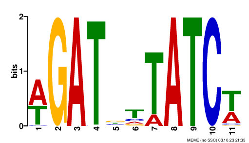

Figure 2: GATA3 motif variants 1

### 2.1.2 MAST

After the finding of GATA3-like de novo motif, we will then perform `MAST` to query this motif in all GATA3 peak regions (101bp window), and look for motif coordinates within the peak regions.  
First convert bed filr for all GATA3 peak regions to fasta.

```bash
fastaFromBed -fi $genome -bed ${dir}GATA_ChIP_summit_100window.bed -fo GATA_ChIP_summit_100window.fasta
```

```bash
wc -l Exhaustive_MEME_MAST_round1to8/GATA_ChIP_summit_100window.fasta
head -6 Exhaustive_MEME_MAST_round1to8/GATA_ChIP_summit_100window.fasta
```

```
##   193736 Exhaustive_MEME_MAST_round1to8/GATA_ChIP_summit_100window.fasta
## >chr1:827330-827431
## AGCATTTCCGGGCGTCGCGGGACTCCCCGCCGACAGGAGGGCGGTTGCCGAGCCTGTGACATCCGCGGAGACCAGCAGACCCCGGGTGTGGAGGACGCCGC
## >chr1:845746-845847
## TCTTTACCATCAGACACTCCTTAAGTTAAGAGCTAGATAATTCGCTCAGCCTCAGGCCAGGCCGAGCCTCACTCTAGAAGTCACATTCCTGAGGTGTAGGG
## >chr1:869447-869548
## GAACAGCTATGTATTtatctatcatctatctatctacctgcctatcatctatctatctatttactatctatctTTTCTACCTTTCGCCATCAAGAGCTTCA
```

MAST:

```bash
mast -hit_list -best GATA_ChIP_top10000_motif.meme_output/meme.txt GATA_ChIP_summit_100window.fasta > mast_GATA3_PSWM_in_peaks_round1.txt

Rscript /home/FCAM/ssun/scripts/parse_mast_to_coordinates.R mast_GATA3_PSWM_in_peaks_round1.txt
```

```bash
wc -l Exhaustive_MEME_MAST_round1to8/mast_GATA3_PSWM_in_peaks_round1.txt
head -5 Exhaustive_MEME_MAST_round1to8/mast_GATA3_PSWM_in_peaks_round1.txt
wc -l Exhaustive_MEME_MAST_round1to8/mast_GATA3_PSWM_in_peaks_round1.bed
head -5 Exhaustive_MEME_MAST_round1to8/mast_GATA3_PSWM_in_peaks_round1.bed
```

```
##    11430 Exhaustive_MEME_MAST_round1to8/mast_GATA3_PSWM_in_peaks_round1.txt
## # Best single (non-overlapping) hit for each motif in all sequences from "GATA_ChIP_summit_100window.fasta".
## # sequence_name (strand+/-)motif id alt_id hit_start hit_end score hit_p-value
## chr1:1080506-1080607 +1 WGATBTTATCW MEME-1 60 70   840.25 9.55e-05
## chr1:1238187-1238288 -1 WGATBTTATCW MEME-1 32 42  1413.00 9.62e-06
## chr1:1686381-1686482 -1 WGATBTTATCW MEME-1 24 34  1176.00 3.73e-05
##    11427 Exhaustive_MEME_MAST_round1to8/mast_GATA3_PSWM_in_peaks_round1.bed
## chr1 1080566 1080576 840.25  9.55e-05    +   1
## chr1 1238219 1238229 1413    9.62e-06    -   1
## chr1 1686405 1686415 1176    3.73e-05    -   1
## chr1 1741170 1741180 1176    3.73e-05    -   1
## chr1 2002016 2002026 1176    3.73e-05    +   1
```

Then we use `intersectBed` with `-v` option to find GATA3 peaks without GATA3-like motif1 (use the queried motif1 coordinates).

```bash
#peaks without motif1
intersectBed -v -a ${dir}GATA_ChIP_summit_100window.bed -b mast_GATA3_PSWM_in_peaks_round1.bed > without_motifs_1.bed #85440
fastaFromBed -fi $genome -bed without_motifs_1.bed -fo without_motifs_1.fasta
```

```bash
wc -l Exhaustive_MEME_MAST_round1to8/without_motifs_1.bed
head -3 Exhaustive_MEME_MAST_round1to8/without_motifs_1.bed
wc -l Exhaustive_MEME_MAST_round1to8/without_motifs_1.fasta
head -6 Exhaustive_MEME_MAST_round1to8/without_motifs_1.fasta
```

```
##    85440 Exhaustive_MEME_MAST_round1to8/without_motifs_1.bed
## chr1 827330  827431  GATA_ChIP_peak_28   9.30478
## chr1 845746  845847  GATA_ChIP_peak_29   541.83
## chr1 869447  869548  GATA_ChIP_peak_30   3.78065
##   170880 Exhaustive_MEME_MAST_round1to8/without_motifs_1.fasta
## >chr1:827330-827431
## AGCATTTCCGGGCGTCGCGGGACTCCCCGCCGACAGGAGGGCGGTTGCCGAGCCTGTGACATCCGCGGAGACCAGCAGACCCCGGGTGTGGAGGACGCCGC
## >chr1:845746-845847
## TCTTTACCATCAGACACTCCTTAAGTTAAGAGCTAGATAATTCGCTCAGCCTCAGGCCAGGCCGAGCCTCACTCTAGAAGTCACATTCCTGAGGTGTAGGG
## >chr1:869447-869548
## GAACAGCTATGTATTtatctatcatctatctatctacctgcctatcatctatctatctatttactatctatctTTTCTACCTTTCGCCATCAAGAGCTTCA
```

## 2.2 MEME-Round2:

### 2.2.1 find de novo motifs

**Sort** and select the top 10,000 peaks from **GATA3 peaks without motif1**.

```bash
# select top 10000
sort -nrk5,5 without_motifs_1.bed | head -n 10000 > without_motifs_1_top10000.bed
fastaFromBed -fi $genome -bed without_motifs_1_top10000.bed -fo without_motifs_1_top10000.fasta
```

```bash
wc -l Exhaustive_MEME_MAST_round1to8/without_motifs_1_top10000.bed
head -3 Exhaustive_MEME_MAST_round1to8/without_motifs_1_top10000.bed
wc -l Exhaustive_MEME_MAST_round1to8/without_motifs_1_top10000.fasta
head -6 Exhaustive_MEME_MAST_round1to8/without_motifs_1_top10000.fasta
```

```
##    10000 Exhaustive_MEME_MAST_round1to8/without_motifs_1_top10000.bed
## chr17    61231334    61231435    GATA_ChIP_peak_31668a   19079.1
## chr20    54456608    54456709    GATA_ChIP_peak_45471a   13349.5
## chr20    57264350    57264451    GATA_ChIP_peak_45539a   12701.1
##    20000 Exhaustive_MEME_MAST_round1to8/without_motifs_1_top10000.fasta
## >chr17:61231334-61231435
## ttgtcagatgcatagtttgagaatattttctctcattctttaggttgcctgtttactctcttgatagtgtcttttTATTGCTttatctccattttacagat
## >chr20:54456608-54456709
## accttttacagatgagaaaGTAGTAATTTGTTTAGAGcaggatttcccaaccccagcactattgacatttggtgccagataattctttgctacggctgccc
## >chr20:57264350-57264451
## GTTCGGGTTTTCGCAGCAAGTTACACAAGTAGAATGAAAGCGGCTCAGGAAACAGCGCTATCGGGGTGTGTTATCTCGGAAACCAAATATTTGATCATCAG
```

Perform **MEME** to find most enriched de novo motif in top 10,000 GATA3 peaks without motif1.

```bash
# MEME-classic
meme -p 48 -oc GATA3_without_motif1_top10000_output -nmotifs 1 -objfun classic -csites 20000 -searchsize 0 -minw 4 -maxw 20 -revcomp -dna -bfile hg38_bkgrnd.txt -maxsize 100000000 without_motifs_1_top10000.fasta
```

The top enriched de novo motif found in the top 10,000 GATA3 peaks (without motif1) match to GATA3.

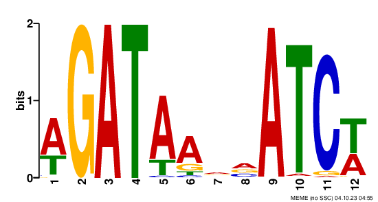

Figure 3: GATA3 motif variants 2

### 2.2.2 MAST

Now we want to use `MAST` to query the 2nd GATA-3 like de novo motif from all GATA3 peaks that do not have GATA3-like motif1.

```bash
mast -hit_list -best GATA3_without_motif1_top10000_output/meme.txt without_motifs_1.fasta > mast_GATA3_PSWM_in_peaks_round2.txt

Rscript /home/FCAM/ssun/scripts/parse_mast_to_coordinates.R mast_GATA3_PSWM_in_peaks_round2.txt
```

```bash
wc -l Exhaustive_MEME_MAST_round1to8/mast_GATA3_PSWM_in_peaks_round2.txt
head -5 Exhaustive_MEME_MAST_round1to8/mast_GATA3_PSWM_in_peaks_round2.txt
wc -l Exhaustive_MEME_MAST_round1to8/mast_GATA3_PSWM_in_peaks_round2.bed #10460
head -5 Exhaustive_MEME_MAST_round1to8/mast_GATA3_PSWM_in_peaks_round2.bed
```

```
##    10463 Exhaustive_MEME_MAST_round1to8/mast_GATA3_PSWM_in_peaks_round2.txt
## # Best single (non-overlapping) hit for each motif in all sequences from "without_motifs_1.fasta".
## # sequence_name (strand+/-)motif id alt_id hit_start hit_end score hit_p-value
## chr1:996099-996200 +1 WGATAARVATCW MEME-1 50 61  1256.25 2.21e-05
## chr1:3213828-3213929 -1 WGATAARVATCW MEME-1 47 58  1455.15 5.80e-06
## chr1:5603406-5603507 -1 WGATAARVATCW MEME-1 11 22   977.79 8.07e-05
##    10460 Exhaustive_MEME_MAST_round1to8/mast_GATA3_PSWM_in_peaks_round2.bed
## chr1 996149  996160  1256.25 2.21e-05    +   1
## chr1 3213875 3213886 1455.15 5.8e-06 -   1
## chr1 5603417 5603428 977.79  8.07e-05    -   1
## chr1 5688630 5688641 1236.36 2.5e-05 +   1
## chr1 5959797 5959808 1276.14 1.96e-05    -   1
```

Then we use `intersectBed` with `-v` option to exclude peaks contains GATA3-like motif2 from peaks contains GATA3-like motif1.

The output file will be GATA3 peak regions (101bp) that do not contain GATA3-like motif 1 and 2.

```bash
#peaks without motif1 and motif2
intersectBed -v -a without_motifs_1.bed -b mast_GATA3_PSWM_in_peaks_round2.bed > without_motifs_12.bed #74979

fastaFromBed -fi $genome -bed without_motifs_12.bed -fo without_motifs_12.fasta
```

```bash
wc -l Exhaustive_MEME_MAST_round1to8/without_motifs_12.bed
head -5 Exhaustive_MEME_MAST_round1to8/without_motifs_12.bed
wc -l Exhaustive_MEME_MAST_round1to8/without_motifs_12.fasta
head -5 Exhaustive_MEME_MAST_round1to8/without_motifs_12.fasta
```

```
##    74979 Exhaustive_MEME_MAST_round1to8/without_motifs_12.bed
## chr1 827330  827431  GATA_ChIP_peak_28   9.30478
## chr1 845746  845847  GATA_ChIP_peak_29   541.83
## chr1 869447  869548  GATA_ChIP_peak_30   3.78065
## chr1 916719  916820  GATA_ChIP_peak_31   7.79887
## chr1 917484  917585  GATA_ChIP_peak_32   75.0238
##   149958 Exhaustive_MEME_MAST_round1to8/without_motifs_12.fasta
## >chr1:827330-827431
## AGCATTTCCGGGCGTCGCGGGACTCCCCGCCGACAGGAGGGCGGTTGCCGAGCCTGTGACATCCGCGGAGACCAGCAGACCCCGGGTGTGGAGGACGCCGC
## >chr1:845746-845847
## TCTTTACCATCAGACACTCCTTAAGTTAAGAGCTAGATAATTCGCTCAGCCTCAGGCCAGGCCGAGCCTCACTCTAGAAGTCACATTCCTGAGGTGTAGGG
## >chr1:869447-869548
```

## 2.3 MEME-Round3:

### 2.3.1 find denovo motif with MEME

Again, **sort** and **select** the top 10,000 peaks from GATA3 peaks without motif 1 and 2 (101bp window).  
Then convert .bed to .fasta.

```bash
# select top 10000
sort -nrk5,5 without_motifs_12.bed | head -n 10000 > without_motifs_12_top10000.bed
fastaFromBed -fi $genome -bed without_motifs_12_top10000.bed -fo without_motifs_12_top10000.fasta
```

```bash
wc -l Exhaustive_MEME_MAST_round1to8/without_motifs_12_top10000.bed
head -5 Exhaustive_MEME_MAST_round1to8/without_motifs_12_top10000.bed
wc -l Exhaustive_MEME_MAST_round1to8/without_motifs_12_top10000.fasta
head -5 Exhaustive_MEME_MAST_round1to8/without_motifs_12_top10000.fasta
```

```
##    10000 Exhaustive_MEME_MAST_round1to8/without_motifs_12_top10000.bed
## chr17    61231334    61231435    GATA_ChIP_peak_31668a   19079.1
## chr20    54456608    54456709    GATA_ChIP_peak_45471a   13349.5
## chr20    57264350    57264451    GATA_ChIP_peak_45539a   12701.1
## chr20    50764358    50764459    GATA_ChIP_peak_45276e   9467.78
## chr17    61336165    61336266    GATA_ChIP_peak_31684    5845.12
##    20000 Exhaustive_MEME_MAST_round1to8/without_motifs_12_top10000.fasta
## >chr17:61231334-61231435
## ttgtcagatgcatagtttgagaatattttctctcattctttaggttgcctgtttactctcttgatagtgtcttttTATTGCTttatctccattttacagat
## >chr20:54456608-54456709
## accttttacagatgagaaaGTAGTAATTTGTTTAGAGcaggatttcccaaccccagcactattgacatttggtgccagataattctttgctacggctgccc
## >chr20:57264350-57264451
```

Perform `MEME`.

```bash
# MEME-classic
meme -p 64 -oc GATA3_without_motif12_top10000_output -nmotifs 1 -objfun classic -csites 20000 -searchsize 0 -minw 4 -maxw 20 -revcomp -dna -bfile hg38_bkgrnd.txt -maxsize 100000000 without_motifs_12_top10000.fasta
```

Top motif enriched in top 10,000 peak (exclude the first round and second round GATA motif) match to GATA3 (single sites)

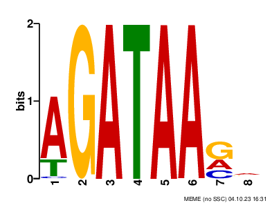

Figure 4: GATA3 motif variants 3

### 2.3.2 MAST

Query the GATA3-like motif3 from GATA3 peaks without motif 1 and 2 (101bp window) and find motif3 coordinates in peak regions.

```bash
mast -hit_list -best GATA3_without_motif12_top10000_output/meme.txt without_motifs_12.fasta > mast_GATA3_PSWM_in_peaks_round3.txt
Rscript /home/FCAM/ssun/scripts/parse_mast_to_coordinates.R mast_GATA3_PSWM_in_peaks_round3.txt
wc -l mast_GATA3_PSWM_in_peaks_round3.bed #5202
```

```bash
wc -l Exhaustive_MEME_MAST_round1to8/mast_GATA3_PSWM_in_peaks_round3.txt
head -5 Exhaustive_MEME_MAST_round1to8/mast_GATA3_PSWM_in_peaks_round3.txt
wc -l Exhaustive_MEME_MAST_round1to8/mast_GATA3_PSWM_in_peaks_round3.bed
head -5 Exhaustive_MEME_MAST_round1to8/mast_GATA3_PSWM_in_peaks_round3.bed
```

```
##     5205 Exhaustive_MEME_MAST_round1to8/mast_GATA3_PSWM_in_peaks_round3.txt
## # Best single (non-overlapping) hit for each motif in all sequences from "without_motifs_12.fasta".
## # sequence_name (strand+/-)motif id alt_id hit_start hit_end score hit_p-value
## chr1:7912015-7912116 -1 AGATAARR MEME-1 35 42  1207.40 2.16e-05
## chr1:8395017-8395118 +1 AGATAARR MEME-1 58 65  1186.58 3.93e-05
## chr1:8571689-8571790 -1 AGATAARR MEME-1 52 59  1165.76 5.70e-05
##     5202 Exhaustive_MEME_MAST_round1to8/mast_GATA3_PSWM_in_peaks_round3.bed
## chr1 7912050 7912057 1207.4  2.16e-05    -   1
## chr1 8395075 8395082 1186.58 3.93e-05    +   1
## chr1 8571741 8571748 1165.76 5.7e-05 -   1
## chr1 8635951 8635958 1207.4  2.16e-05    -   1
## chr1 10507886    10507893    1207.4  2.16e-05    +   1
```

Use `intersectBed` with `-v` to find GATA3 peaks without motif 123.

```bash
#peaks without motif1 and motif2 and motif3
intersectBed -v -a without_motifs_12.bed -b mast_GATA3_PSWM_in_peaks_round3.bed > without_motifs_123.bed #69777
fastaFromBed -fi $genome -bed without_motifs_123.bed -fo without_motifs_123.fasta
```

```bash
wc -l Exhaustive_MEME_MAST_round1to8/without_motifs_123.bed
head -5 Exhaustive_MEME_MAST_round1to8/without_motifs_123.bed
wc -l Exhaustive_MEME_MAST_round1to8/without_motifs_123.fasta
head -5 Exhaustive_MEME_MAST_round1to8/without_motifs_123.fasta
```

```
##    69777 Exhaustive_MEME_MAST_round1to8/without_motifs_123.bed
## chr1 827330  827431  GATA_ChIP_peak_28   9.30478
## chr1 845746  845847  GATA_ChIP_peak_29   541.83
## chr1 869447  869548  GATA_ChIP_peak_30   3.78065
## chr1 916719  916820  GATA_ChIP_peak_31   7.79887
## chr1 917484  917585  GATA_ChIP_peak_32   75.0238
##   139554 Exhaustive_MEME_MAST_round1to8/without_motifs_123.fasta
## >chr1:827330-827431
## AGCATTTCCGGGCGTCGCGGGACTCCCCGCCGACAGGAGGGCGGTTGCCGAGCCTGTGACATCCGCGGAGACCAGCAGACCCCGGGTGTGGAGGACGCCGC
## >chr1:845746-845847
## TCTTTACCATCAGACACTCCTTAAGTTAAGAGCTAGATAATTCGCTCAGCCTCAGGCCAGGCCGAGCCTCACTCTAGAAGTCACATTCCTGAGGTGTAGGG
## >chr1:869447-869548
```

## 2.4 brief summary:

In the first 3 rounds of MEME analysis, we are asking MEME to find only 1 de novo motif, and these top enriched motifs match to GATA3.  
In the next few rounds, we will see cases where the top enriched de novo motif found by MEME do not match to GATA3.  
In these cases, we would increase the number of de novo motif we ask MEME to find use `nmotifs` option, and see if the second or third enriched de novo motif match to GATA3.

## 2.5 MEME-Round4:

### 2.5.1 find 1st de novo motif

Sort and select top 10,000 peaks from GATA3 peaks without GATA3-like motif123.

```bash
# select top 10000
sort -nrk5,5 without_motifs_123.bed | head -n 10000 > without_motifs_123_top10000.bed
fastaFromBed -fi $genome -bed without_motifs_123_top10000.bed -fo without_motifs_123_top10000.fasta
```

```bash
# MEME-classic
meme -p 64 -oc GATA3_without_motif123_top10000_output -nmotifs 1 -objfun classic -csites 20000 -searchsize 0 -minw 4 -maxw 20 -revcomp -dna -bfile hg38_bkgrnd.txt -maxsize 100000000 without_motifs_123_top10000.fasta
```

Top motif in top 10,000 peak (exclude the first/second/third round GATA motifs) match to **FOX**.

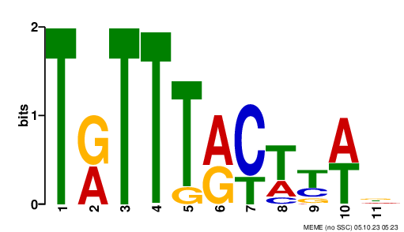

### 2.5.2 find 2nd de novo motif

repeat previous MEME-classic with `-nmotifs` set to 2.

```bash
# MEME-classic
meme -p 64 -oc GATA3_without_motif123_top10000_output_1 -nmotifs 2 -objfun classic -csites 20000 -searchsize 0 -minw 4 -maxw 20 -revcomp -dna -bfile hg38_bkgrnd.txt -maxsize 100000000 without_motifs_123_top10000.fasta
```

Second motif in top 10,000 peak (exclude the first/second/third round GATA motifs) match to GATA3 (4 spaces between half sites)

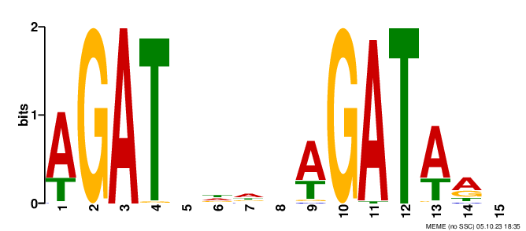

Figure 6: GATA3 motif variants 4

### 2.5.3 MAST

First isolate individual memes from the MEME output meme.txt file.

```bash
wget https://raw.githubusercontent.com/sysunn/siyu_daily_update/main/December_2023/MEME_individual_from_db_python3.py
python MEME_individual_from_db_python3.py -i GATA3_without_motif123_top10000_output_1/meme.txt
        # output: # AGATNDWNAGATARN_meme.txt ---motif4 (match to GATA3)
                  # TRTTTRCTYWD_meme.txt ---FOX

mkdir individual_meme
#MEME-round1 motif1
cp GATA_ChIP_top10000_motif.meme_output/meme.txt individual_meme/GATAmotif1_meme.txt
#MEME-round2 motif2
cp GATA3_without_motif1_top10000_output/meme.txt individual_meme/GATAmotif2_meme.txt
#MEME-round3 motif3
cp GATA3_without_motif12_top10000_output/meme.txt individual_meme/GATAmotif3_meme.txt
#MEME-round4 motif4
cp AGATNDWNAGATARN_meme.txt individual_meme/GATAmotif4_meme.txt

rm *meme.txt
```

```bash
cat Exhaustive_MEME_MAST_round1to8/individual_meme/GATAmotif4_meme.txt
```

```
## MEME version 5.4.1 (Release date: Sat Aug 21 19:23:23 2021 -0700)
##
## ALPHABET= ACGT
##
## strands: + -
##
## A 0.295 C 0.205 G 0.205 T 0.295
##
## MOTIF    AGATNDWNAGATARN
## letter-probability matrix: alength= 4 w= 15 nsites= 1064 E= 1.8e-469
##  0.718985  0.017857  0.000000  0.263158
##  0.000000  0.000000  1.000000  0.000000
##  1.000000  0.000000  0.000000  0.000000
##  0.000940  0.000000  0.015038  0.984023
##  0.218045  0.192669  0.331767  0.257519
##  0.325188  0.120301  0.208647  0.345865
##  0.432331  0.157895  0.186090  0.223684
##  0.296992  0.262218  0.230263  0.210526
##  0.631579  0.031015  0.039474  0.297932
##  0.000000  0.000000  1.000000  0.000000
##  0.981203  0.000000  0.000000  0.018797
##  0.000000  0.000000  0.000000  1.000000
##  0.671992  0.013158  0.022556  0.292293
##  0.512218  0.071429  0.256579  0.159774
##  0.345865  0.187030  0.260338  0.206767
```

Use `MAST` to query this GATA3-like motif4 from GATA3 peaks without motif123.

```bash
mast -hit_list -best individual_meme/GATAmotif4_meme.txt without_motifs_123.fasta > mast_GATA3_PSWM_in_peaks_round4.txt #5668

Rscript /home/FCAM/ssun/scripts/parse_mast_to_coordinates.R mast_GATA3_PSWM_in_peaks_round4.txt #5665
```

```bash
wc -l Exhaustive_MEME_MAST_round1to8/mast_GATA3_PSWM_in_peaks_round4.txt
head -5 Exhaustive_MEME_MAST_round1to8/mast_GATA3_PSWM_in_peaks_round4.txt
wc -l Exhaustive_MEME_MAST_round1to8/mast_GATA3_PSWM_in_peaks_round4.bed #5665
head -5 Exhaustive_MEME_MAST_round1to8/mast_GATA3_PSWM_in_peaks_round4.bed
```

```
##     5668 Exhaustive_MEME_MAST_round1to8/mast_GATA3_PSWM_in_peaks_round4.txt
## # Best single (non-overlapping) hit for each motif in all sequences from "without_motifs_123.fasta".
## # sequence_name (strand+/-)motif id alt_id hit_start hit_end score hit_p-value
## chr1:869447-869548 -1 AGATNDWNAGATARN - 21 35  1223.57 5.03e-05
## chr1:917484-917585 +1 AGATNDWNAGATARN - 20 34  1111.37 7.37e-05
## chr1:3927027-3927128 -1 AGATNDWNAGATARN - 35 49  1691.04 2.59e-06
##     5665 Exhaustive_MEME_MAST_round1to8/mast_GATA3_PSWM_in_peaks_round4.bed
## chr1 869468  869482  1223.57 5.03e-05    -   1
## chr1 917504  917518  1111.37 7.37e-05    +   1
## chr1 3927062 3927076 1691.04 2.59e-06    -   1
## chr1 4659255 4659269 1691.04 2.59e-06    +   1
## chr1 5406564 5406578 1747.14 1.19e-06    +   1
```

Use `intersectBed` to exclude peaks that contains motif4 from GATA3 peaks without motif 123.  
Then convert to fasta.

```bash
# From peaks (without motif1, 2, 3), exclude peaks with motif4
intersectBed -v -a without_motifs_123.bed -b mast_GATA3_PSWM_in_peaks_round4.bed > without_motifs_1234.bed #64112
fastaFromBed -fi $genome -bed without_motifs_1234.bed -fo without_motifs_1234.fasta
```

```bash
wc -l Exhaustive_MEME_MAST_round1to8/without_motifs_1234.bed
head -5 Exhaustive_MEME_MAST_round1to8/without_motifs_1234.bed
wc -l Exhaustive_MEME_MAST_round1to8/without_motifs_1234.fasta
head -5 Exhaustive_MEME_MAST_round1to8/without_motifs_1234.fasta
```

```
##    64112 Exhaustive_MEME_MAST_round1to8/without_motifs_1234.bed
## chr1 827330  827431  GATA_ChIP_peak_28   9.30478
## chr1 845746  845847  GATA_ChIP_peak_29   541.83
## chr1 916719  916820  GATA_ChIP_peak_31   7.79887
## chr1 924803  924904  GATA_ChIP_peak_33   3.78065
## chr1 966603  966704  GATA_ChIP_peak_34   3.78065
##   128224 Exhaustive_MEME_MAST_round1to8/without_motifs_1234.fasta
## >chr1:827330-827431
## AGCATTTCCGGGCGTCGCGGGACTCCCCGCCGACAGGAGGGCGGTTGCCGAGCCTGTGACATCCGCGGAGACCAGCAGACCCCGGGTGTGGAGGACGCCGC
## >chr1:845746-845847
## TCTTTACCATCAGACACTCCTTAAGTTAAGAGCTAGATAATTCGCTCAGCCTCAGGCCAGGCCGAGCCTCACTCTAGAAGTCACATTCCTGAGGTGTAGGG
## >chr1:916719-916820
```

## 2.6 MEME-Round5:

### 2.6.1 find de novo motif

**Sort** and **select** the top 10,000 peaks from peaks without motif1234.  
And convert to fasta.

```bash
# select top 10000
sort -nrk5,5 without_motifs_1234.bed | head -n 10000 > without_motifs_1234_top10000.bed
fastaFromBed -fi $genome -bed without_motifs_1234_top10000.bed -fo without_motifs_1234_top10000.fasta
```

```bash
wc -l Exhaustive_MEME_MAST_round1to8/without_motifs_1234_top10000.bed
head -5 Exhaustive_MEME_MAST_round1to8/without_motifs_1234_top10000.bed
wc -l Exhaustive_MEME_MAST_round1to8/without_motifs_1234_top10000.fasta
head -5 Exhaustive_MEME_MAST_round1to8/without_motifs_1234_top10000.fasta
```

```
##    10000 Exhaustive_MEME_MAST_round1to8/without_motifs_1234_top10000.bed
## chr17    61231334    61231435    GATA_ChIP_peak_31668a   19079.1
## chr20    54456608    54456709    GATA_ChIP_peak_45471a   13349.5
## chr20    57264350    57264451    GATA_ChIP_peak_45539a   12701.1
## chr20    50764358    50764459    GATA_ChIP_peak_45276e   9467.78
## chr17    61336165    61336266    GATA_ChIP_peak_31684    5845.12
##    20000 Exhaustive_MEME_MAST_round1to8/without_motifs_1234_top10000.fasta
## >chr17:61231334-61231435
## ttgtcagatgcatagtttgagaatattttctctcattctttaggttgcctgtttactctcttgatagtgtcttttTATTGCTttatctccattttacagat
## >chr20:54456608-54456709
## accttttacagatgagaaaGTAGTAATTTGTTTAGAGcaggatttcccaaccccagcactattgacatttggtgccagataattctttgctacggctgccc
## >chr20:57264350-57264451
```

In previous run, we have already found top enriched de novo motif match to factors other than GATA3. We would expect to see that FOX-like motif reappear in this round.

Thus, we will search for more motifs (`-nmotifs`) with MEME.

```bash
#!/bin/bash
#SBATCH --job-name=meme4.sh
#SBATCH -N 6
#SBATCH -n 6
#SBATCH -c 16
#SBATCH -p general
#SBATCH --qos=general
#SBATCH --mem=35G
#SBATCH --mail-type=ALL
#SBATCH --mail-user=ssun@uchc.edu
#SBATCH -o streme4.sh_%j.out
#SBATCH -e streme4.sh_%j.err

hostname
export TMPDIR="${HOME}/temp"
module load meme/5.4.1

# MEME-classic
meme -p 96 -oc GATA3_without_motif1234_top10000_output -nmotifs 3 -objfun classic -csites 20000 -searchsize 0 -minw 4 -maxw 20 -revcomp -dna -bfile hg38_bkgrnd.txt -maxsize 100000000 without_motifs_1234_top10000.fasta
```

To confirm if use `nmotif==1`, the top motif will be factor not match with GATA3, I am running this top 10,000 peaks with `-nmotif 1` here.

```bash
meme -p 96 -oc GATA3_without_motif1234_top10000_output_testsingle -nmotifs 1 -objfun classic -csites 20000 -searchsize 0 -minw 4 -maxw 20 -revcomp -dna -bfile hg38_bkgrnd.txt -maxsize 100000000 without_motifs_1234_top10000.fasta
```

While finding only one motif with MEME, we are getting FOX again.

The third de novo motif found in top 10,000 peak (exclude the 1234 round GATA motifs) match to GATA3.

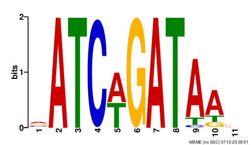

Figure 7: GATA3 motif variants 5

### 2.6.2 MAST

First, isolate individual memes from the MEME output meme.txt file.

```r
#wget https://raw.githubusercontent.com/sysunn/siyu_daily_update/main/December_2023/MEME_individual_from_db_python3.py
python MEME_individual_from_db_python3.py -i GATA3_without_motif1234_top10000_output/meme.txt
        # BTTATCWGATB_meme.txt    ---motif5 (match to GATA3)
cp BTTATCWGATB_meme.txt individual_meme/GATAmotif5_meme.txt
rm *meme.txt
```

```bash
cat Exhaustive_MEME_MAST_round1to8/individual_meme/GATAmotif5_meme.txt
```

```
## MEME version 5.4.1 (Release date: Sat Aug 21 19:23:23 2021 -0700)
##
## ALPHABET= ACGT
##
## strands: + -
##
## A 0.295 C 0.205 G 0.205 T 0.295
##
## MOTIF    BTTATCWGATB
## letter-probability matrix: alength= 4 w= 11 nsites= 780 E= 3.1e-321
##  0.125641  0.291026  0.296154  0.287179
##  0.176923  0.143590  0.011538  0.667949
##  0.112821  0.000000  0.041026  0.846154
##  1.000000  0.000000  0.000000  0.000000
##  0.000000  0.000000  0.000000  1.000000
##  0.000000  1.000000  0.000000  0.000000
##  0.456410  0.000000  0.000000  0.543590
##  0.000000  0.003846  0.996154  0.000000
##  1.000000  0.000000  0.000000  0.000000
##  0.000000  0.000000  0.000000  1.000000
##  0.106410  0.297436  0.238462  0.357692
```

Use `MAST` to query this GATA3-like motif5 from GATA3 peaks without motif 1234 (101bp window) and find the motif coordinates within peak regions.

```bash
# Mast find peaks with motif5
mast -hit_list -best individual_meme/GATAmotif5_meme.txt without_motifs_1234.fasta > mast_GATA3_PSWM_in_peaks_round5.txt
Rscript /home/FCAM/ssun/scripts/parse_mast_to_coordinates.R mast_GATA3_PSWM_in_peaks_round5.txt
wc -l mast_GATA3_PSWM_in_peaks_round5.bed #3564
```

```bash
wc -l Exhaustive_MEME_MAST_round1to8/mast_GATA3_PSWM_in_peaks_round5.txt
head -5 Exhaustive_MEME_MAST_round1to8/mast_GATA3_PSWM_in_peaks_round5.txt
wc -l Exhaustive_MEME_MAST_round1to8/mast_GATA3_PSWM_in_peaks_round5.bed
head -5 Exhaustive_MEME_MAST_round1to8/mast_GATA3_PSWM_in_peaks_round5.bed
```

```
##     3567 Exhaustive_MEME_MAST_round1to8/mast_GATA3_PSWM_in_peaks_round5.txt
## # Best single (non-overlapping) hit for each motif in all sequences from "without_motifs_1234.fasta".
## # sequence_name (strand+/-)motif id alt_id hit_start hit_end score hit_p-value
## chr1:1858856-1858957 +1 BTTATCWGATB - 69 79  1196.17 5.23e-05
## chr1:3948545-3948646 -1 BTTATCWGATB - 74 84  1469.94 1.62e-05
## chr1:6317549-6317650 +1 BTTATCWGATB - 83 93  1433.43 2.15e-05
##     3564 Exhaustive_MEME_MAST_round1to8/mast_GATA3_PSWM_in_peaks_round5.bed
## chr1 1858925 1858935 1196.17 5.23e-05    +   1
## chr1 3948619 3948629 1469.94 1.62e-05    -   1
## chr1 6317632 6317642 1433.43 2.15e-05    +   1
## chr1 8121183 8121193 1013.66 8.51e-05    -   1
## chr1 8137811 8137821 1634.2  6.22e-06    +   1
```

Use `intersectBed` to find peaks without GATA3-like motif 12345.

```bash
# From peaks (without motif1, 2, 3,4), exclude peaks with motif5
intersectBed -v -a without_motifs_1234.bed -b mast_GATA3_PSWM_in_peaks_round5.bed > without_motifs_12345.bed #60548
fastaFromBed -fi $genome -bed without_motifs_12345.bed -fo without_motifs_12345.fasta
```

```bash
wc -l Exhaustive_MEME_MAST_round1to8/without_motifs_12345.bed
head -5 Exhaustive_MEME_MAST_round1to8/without_motifs_12345.bed
wc -l Exhaustive_MEME_MAST_round1to8/without_motifs_12345.fasta
head -5 Exhaustive_MEME_MAST_round1to8/without_motifs_12345.fasta
```

```
##    60548 Exhaustive_MEME_MAST_round1to8/without_motifs_12345.bed
## chr1 827330  827431  GATA_ChIP_peak_28   9.30478
## chr1 845746  845847  GATA_ChIP_peak_29   541.83
## chr1 916719  916820  GATA_ChIP_peak_31   7.79887
## chr1 924803  924904  GATA_ChIP_peak_33   3.78065
## chr1 966603  966704  GATA_ChIP_peak_34   3.78065
##   121096 Exhaustive_MEME_MAST_round1to8/without_motifs_12345.fasta
## >chr1:827330-827431
## AGCATTTCCGGGCGTCGCGGGACTCCCCGCCGACAGGAGGGCGGTTGCCGAGCCTGTGACATCCGCGGAGACCAGCAGACCCCGGGTGTGGAGGACGCCGC
## >chr1:845746-845847
## TCTTTACCATCAGACACTCCTTAAGTTAAGAGCTAGATAATTCGCTCAGCCTCAGGCCAGGCCGAGCCTCACTCTAGAAGTCACATTCCTGAGGTGTAGGG
## >chr1:916719-916820
```

## 2.7 MEME-Round6:

### 2.7.1 find de novo motifs

**sort** and **select** top 10,000 peaks from GATA3 peaks without motif12345.

```bash
# select top 10000
sort -nrk5,5 without_motifs_12345.bed | head -n 10000 > without_motifs_12345_top10000.bed
fastaFromBed -fi $genome -bed without_motifs_12345_top10000.bed -fo without_motifs_12345_top10000.fasta
```

```bash
wc -l Exhaustive_MEME_MAST_round1to8/without_motifs_12345_top10000.bed
head -5 Exhaustive_MEME_MAST_round1to8/without_motifs_12345_top10000.bed
wc -l Exhaustive_MEME_MAST_round1to8/without_motifs_12345_top10000.fasta
head -5 Exhaustive_MEME_MAST_round1to8/without_motifs_12345_top10000.fasta
```

```
##    10000 Exhaustive_MEME_MAST_round1to8/without_motifs_12345_top10000.bed
## chr17    61231334    61231435    GATA_ChIP_peak_31668a   19079.1
## chr20    54456608    54456709    GATA_ChIP_peak_45471a   13349.5
## chr20    57264350    57264451    GATA_ChIP_peak_45539a   12701.1
## chr20    50764358    50764459    GATA_ChIP_peak_45276e   9467.78
## chr17    61336165    61336266    GATA_ChIP_peak_31684    5845.12
##    20000 Exhaustive_MEME_MAST_round1to8/without_motifs_12345_top10000.fasta
## >chr17:61231334-61231435
## ttgtcagatgcatagtttgagaatattttctctcattctttaggttgcctgtttactctcttgatagtgtcttttTATTGCTttatctccattttacagat
## >chr20:54456608-54456709
## accttttacagatgagaaaGTAGTAATTTGTTTAGAGcaggatttcccaaccccagcactattgacatttggtgccagataattctttgctacggctgccc
## >chr20:57264350-57264451
```

Same reason as before, since we have found top enriched de novo motif no longer match to GATA3, we will loosen the `-nmotif` option to 3.

```r
#!/bin/bash
#SBATCH --job-name=meme5.sh
#SBATCH -N 6
#SBATCH -n 6
#SBATCH -c 16
#SBATCH -p general
#SBATCH --qos=general
#SBATCH --mem=35G
#SBATCH --mail-type=ALL
#SBATCH --mail-user=ssun@uchc.edu
#SBATCH -o meme5.sh_%j.out
#SBATCH -e meme5.sh_%j.err

hostname
export TMPDIR="${HOME}/temp"
module load meme/5.4.1
# MEME-classic
meme -p 96 -oc GATA3_without_motif12345_top10000_output -nmotifs 3 -objfun classic -csites 20000 -searchsize 0 -minw 4 -maxw 20 -revcomp -dna -bfile hg38_bkgrnd.txt -maxsize 100000000 without_motifs_12345_top10000.fasta
```

The third de novo motif found in top 10,000 peak (exclude the 12345 round GATA motifs) match to GATA3.

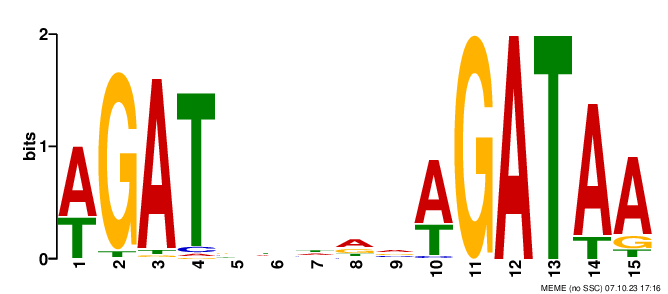

Figure 8: GATA3 motif variants 6

### 2.7.2 MAST

First isolate individual memes from the MEME output meme.txt file, and move the GATA3-like motif to a separate folder.

```bash
#wget https://raw.githubusercontent.com/sysunn/siyu_daily_update/main/December_2023/MEME_individual_from_db_python3.py
python MEME_individual_from_db_python3.py -i GATA3_without_motif12345_top10000_output/meme.txt
        # WGATBDHRVAGATAA_meme.txt    ---motif6 (match to GATA3)
cp WGATBDHRVAGATAA_meme.txt individual_meme/GATAmotif6_meme.txt
rm *meme.txt
```

```bash
cat Exhaustive_MEME_MAST_round1to8/individual_meme/GATAmotif6_meme.txt
```

```
## MEME version 5.4.1 (Release date: Sat Aug 21 19:23:23 2021 -0700)
##
## ALPHABET= ACGT
##
## strands: + -
##
## A 0.295 C 0.205 G 0.205 T 0.295
##
## MOTIF    WGATBDHRVAGATAA
## letter-probability matrix: alength= 4 w= 15 nsites= 818 E= 2.3e-331
##  0.625917  0.003667  0.001222  0.369193
##  0.002445  0.008557  0.951100  0.037897
##  0.943765  0.008557  0.017115  0.030562
##  0.022005  0.040342  0.015892  0.921760
##  0.135697  0.289731  0.300733  0.273839
##  0.311736  0.149144  0.217604  0.321516
##  0.309291  0.202934  0.139364  0.348411
##  0.446210  0.106357  0.266504  0.180929
##  0.353301  0.259169  0.265281  0.122249
##  0.645477  0.034230  0.001222  0.319071
##  0.000000  0.000000  1.000000  0.000000
##  1.000000  0.000000  0.000000  0.000000
##  0.000000  0.000000  0.000000  1.000000
##  0.849633  0.000000  0.000000  0.150367
##  0.764059  0.015892  0.133252  0.086797
```

Then use `MAST` to query GATA3-like motif6 from GATA3 peaks without motif 12345.  
The output contains the motif coordinated within peak regions (101bp).

```bash
# Mast find peaks with motif6
mast -hit_list -best individual_meme/GATAmotif6_meme.txt without_motifs_12345.fasta > mast_GATA3_PSWM_in_peaks_round6.txt
Rscript /home/FCAM/ssun/scripts/parse_mast_to_coordinates.R mast_GATA3_PSWM_in_peaks_round6.txt
wc -l mast_GATA3_PSWM_in_peaks_round6.bed #4510
```

```bash
wc -l Exhaustive_MEME_MAST_round1to8/mast_GATA3_PSWM_in_peaks_round6.txt
head -5 Exhaustive_MEME_MAST_round1to8/mast_GATA3_PSWM_in_peaks_round6.txt
wc -l Exhaustive_MEME_MAST_round1to8/mast_GATA3_PSWM_in_peaks_round6.bed #4510
head -5 Exhaustive_MEME_MAST_round1to8/mast_GATA3_PSWM_in_peaks_round6.bed
```

```
##     4513 Exhaustive_MEME_MAST_round1to8/mast_GATA3_PSWM_in_peaks_round6.txt
## # Best single (non-overlapping) hit for each motif in all sequences from "without_motifs_12345.fasta".
## # sequence_name (strand+/-)motif id alt_id hit_start hit_end score hit_p-value
## chr1:6800878-6800979 -1 WGATBDHRVAGATAA - 38 52  1076.40 8.40e-05
## chr1:6959598-6959699 -1 WGATBDHRVAGATAA - 85 99  1644.31 4.74e-06
## chr1:8015116-8015217 -1 WGATBDHRVAGATAA - 39 53  1845.83 8.64e-07
##     4510 Exhaustive_MEME_MAST_round1to8/mast_GATA3_PSWM_in_peaks_round6.bed
## chr1 6800916 6800930 1076.4  8.4e-05 -   1
## chr1 6959683 6959697 1644.31 4.74e-06    -   1
## chr1 8015155 8015169 1845.83 8.64e-07    -   1
## chr1 8312221 8312235 1369.52 2.22e-05    +   1
## chr1 8421203 8421217 1131.36 6.68e-05    -   1
```

Use `intersectBed` with `-v` option to find peaks without motif 123456.

And convert to fasta.

```bash
# From peaks (without motif1, 2, 3, 4, 5), exclude peaks with motif6
intersectBed -v -a without_motifs_12345.bed -b mast_GATA3_PSWM_in_peaks_round6.bed > without_motifs_123456.bed #56038
fastaFromBed -fi $genome -bed without_motifs_123456.bed -fo without_motifs_123456.fasta
```

```bash
wc -l Exhaustive_MEME_MAST_round1to8/without_motifs_123456.bed
head -5 Exhaustive_MEME_MAST_round1to8/without_motifs_123456.bed
wc -l Exhaustive_MEME_MAST_round1to8/without_motifs_123456.fasta
head -5 Exhaustive_MEME_MAST_round1to8/without_motifs_123456.fasta
```

```
##    56038 Exhaustive_MEME_MAST_round1to8/without_motifs_123456.bed
## chr1 827330  827431  GATA_ChIP_peak_28   9.30478
## chr1 845746  845847  GATA_ChIP_peak_29   541.83
## chr1 916719  916820  GATA_ChIP_peak_31   7.79887
## chr1 924803  924904  GATA_ChIP_peak_33   3.78065
## chr1 966603  966704  GATA_ChIP_peak_34   3.78065
##   112076 Exhaustive_MEME_MAST_round1to8/without_motifs_123456.fasta
## >chr1:827330-827431
## AGCATTTCCGGGCGTCGCGGGACTCCCCGCCGACAGGAGGGCGGTTGCCGAGCCTGTGACATCCGCGGAGACCAGCAGACCCCGGGTGTGGAGGACGCCGC
## >chr1:845746-845847
## TCTTTACCATCAGACACTCCTTAAGTTAAGAGCTAGATAATTCGCTCAGCCTCAGGCCAGGCCGAGCCTCACTCTAGAAGTCACATTCCTGAGGTGTAGGG
## >chr1:916719-916820
```

## 2.8 MEME—find no GATA3-like motif

```bash
# select top 10000
sort -nrk5,5 without_motifs_123456.bed | head -n 10000 > without_motifs_123456_top10000.bed
fastaFromBed -fi $genome -bed without_motifs_123456_top10000.bed -fo without_motifs_123456_top10000.fasta
```

**-nmotifs 3**

```bash
# MEME-classic
meme -p 40 -oc GATA3_without_motif123456_top10000_output -nmotifs 3 -objfun classic -csites 20000 -searchsize 0 -minw 4 -maxw 20 -revcomp -dna -bfile hg38_bkgrnd.txt -maxsize 100000000 without_motifs_123456_top10000.fasta
```

`MEME` **did not** find de novo motif match to GATA3. I further increase number of `-nmotif` we ask MEME to find in central 101bp window, and did not get GATA3-like motifs.

**-nmotifs 5**

```bash
meme -p 40 -oc GATA3_without_motif123456_top10000_output_test -nmotifs 5 -objfun classic -csites 20000 -searchsize 0 -minw 4 -maxw 20 -revcomp -dna -bfile hg38_bkgrnd.txt -maxsize 100000000 without_motifs_123456_top10000.fasta

# top 5 motifs do not match with GATA
```

**At this point, MEME no longer reports de novo motifs that match to GATA3 in central 101bp window.** so I moved to the other software—**`STREME`**.

# 3 Exhaustive STREME -MAST for GATA3

## 3.1 STREME-round7

### 3.1.1 find de novo motifs at central 101bp window

```bash
module load meme/5.4.1
# perform STREME on peaks (without motif 1,2,3,4,5,6) (101bp window)
streme --o GATA3_without_123456_streme_output --nmotifs 10 --objfun de --bfile hg38_bkgrnd.txt --dna --minw 4 --maxw 15 --p without_motifs_123456.fasta
```

**STREME found 1 motif (out of 10) that matches to GATA3.**

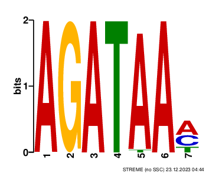

Figure 9: GATA3 motif variants 7

### 3.1.2 MAST

First, save the STREME-found GATA3-like motif file as `AGATAAM_streme.txt` in `individual_meme` folder.

```bash
wget https://raw.githubusercontent.com/sysunn/siyu_daily_update/main/December_2023/STREME_individual_from_db_python3.py
python STREME_individual_from_db_python3.py -i GATA3_without_123456_streme_output/streme.txt
cp 4-AGATAAM_streme.txt individual_meme/AGATAAM_streme.txt
rm *streme.txt
```

```bash
mast -mt 0.0005 -hit_list -best individual_meme/AGATAAM_streme.txt without_motifs_123456.fasta > mast_GATA3_PSWM_in_peaks_round7.txt #8736
Rscript /home/FCAM/ssun/scripts/parse_mast_to_coordinates.R mast_GATA3_PSWM_in_peaks_round7.txt
wc -l mast_GATA3_PSWM_in_peaks_round7.bed #8733
```

```bash
wc -l Exhaustive_MEME_MAST_round1to8/mast_GATA3_PSWM_in_peaks_round7.txt
head -5 Exhaustive_MEME_MAST_round1to8/mast_GATA3_PSWM_in_peaks_round7.txt
wc -l Exhaustive_MEME_MAST_round1to8/mast_GATA3_PSWM_in_peaks_round7.bed
head -5 Exhaustive_MEME_MAST_round1to8/mast_GATA3_PSWM_in_peaks_round7.bed
```

```
##     8736 Exhaustive_MEME_MAST_round1to8/mast_GATA3_PSWM_in_peaks_round7.txt
## # Best single (non-overlapping) hit for each motif in all sequences from "without_motifs_123456.fasta".
## # sequence_name (strand+/-)motif id alt_id hit_start hit_end score hit_p-value
## chr1:845746-845847 +1 4-AGATAAM - 35 41  1169.98 2.70e-04
## chr1:1504971-1505072 +1 4-AGATAAM - 78 84  1284.91 9.58e-05
## chr1:1746897-1746998 +1 4-AGATAAM - 51 57   724.65 4.45e-04
##     8733 Exhaustive_MEME_MAST_round1to8/mast_GATA3_PSWM_in_peaks_round7.bed
## chr1 845781  845787  1169.98 0.00027 +   1
## chr1 1505049 1505055 1284.91 9.58e-05    +   1
## chr1 1746948 1746954 724.65  0.000445    +   1
## chr1 3186512 3186518 1284.91 9.58e-05    -   1
## chr1 6623440 6623446 1241.81 0.000175    +   1
```

Use `intersectBed` to find GATA3 peaks without motif 123456 and the STREME-found motif7.

```bash
# From peaks (without motif1, 2, 3, 4, 5, 6), exclude peaks with motif7 (STREME)
intersectBed -v -a without_motifs_123456.bed -b mast_GATA3_PSWM_in_peaks_round7.bed > without_motifs_123456_7.bed #47305
fastaFromBed -fi $genome -bed without_motifs_123456_7.bed -fo without_motifs_123456_7.fasta
```

```bash
wc -l Exhaustive_MEME_MAST_round1to8/without_motifs_123456_7.bed
head -5 Exhaustive_MEME_MAST_round1to8/without_motifs_123456_7.bed
wc -l Exhaustive_MEME_MAST_round1to8/without_motifs_123456_7.fasta
head -5 Exhaustive_MEME_MAST_round1to8/without_motifs_123456_7.fasta
```

```
##    47305 Exhaustive_MEME_MAST_round1to8/without_motifs_123456_7.bed
## chr1 827330  827431  GATA_ChIP_peak_28   9.30478
## chr1 916719  916820  GATA_ChIP_peak_31   7.79887
## chr1 924803  924904  GATA_ChIP_peak_33   3.78065
## chr1 966603  966704  GATA_ChIP_peak_34   3.78065
## chr1 999458  999559  GATA_ChIP_peak_36   2.11515
##    94610 Exhaustive_MEME_MAST_round1to8/without_motifs_123456_7.fasta
## >chr1:827330-827431
## AGCATTTCCGGGCGTCGCGGGACTCCCCGCCGACAGGAGGGCGGTTGCCGAGCCTGTGACATCCGCGGAGACCAGCAGACCCCGGGTGTGGAGGACGCCGC
## >chr1:916719-916820
## GATAAGAAACTAATAATTTATGCTTCCAGCTCCCGGGGCCGGCGCCGAGGGAAGGTTGGGCCACAGCCTCCCCCGCACTGAGCGGCTGCAGTCCTTTATTG
## >chr1:924803-924904
```

## 3.2 STREME-round8

### 3.2.1 find de novo motifs at central 101bp window

Perform `STREME` to peaks without motif 1234567 (central 101bp window).

```r
module load meme/5.4.1
# perform STREME on peaks (without motif 1,2,3,4,5,6, 7) (101bp central window)
streme --oc GATA3_without_123456_7_streme_output --nmotifs 10 --objfun de --bfile hg38_bkgrnd.txt --dna --minw 4 --maxw 15 --p without_motifs_123456_7.fasta
```

**One of the 10 enriched de novo motif match to GATA3.**

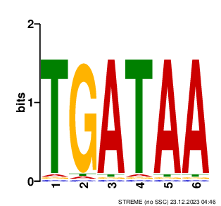

Figure 10: GATA3 motif variants 8

### 3.2.2 MAST

First save the streme motif file as TGATAA_streme.txt in individual_meme folder.

```bash
#wget https://raw.githubusercontent.com/sysunn/siyu_daily_update/main/December_2023/STREME_individual_from_db_python3.py
python STREME_individual_from_db_python3.py -i GATA3_without_123456_7_streme_output/streme.txt
cp 6-TGATAA_streme.txt individual_meme/TGATAA_streme.txt
rm *streme.txt
```

Then use `MAST` to query this motif from all GATA3 peaks without motif 1234567 (101bp window) to find motif coodinates within peak regions.

```bash
# Mast find peaks with motif8 (Streme)
mast -mt 0.0005 -hit_list -best individual_meme/TGATAA_streme.txt without_motifs_123456_7.fasta > mast_GATA3_PSWM_in_peaks_round8.txt
Rscript /home/FCAM/ssun/scripts/parse_mast_to_coordinates.R mast_GATA3_PSWM_in_peaks_round8.txt
wc -l mast_GATA3_PSWM_in_peaks_round8.bed #4452
```

```bash
wc -l Exhaustive_MEME_MAST_round1to8/mast_GATA3_PSWM_in_peaks_round8.txt
head -5 Exhaustive_MEME_MAST_round1to8/mast_GATA3_PSWM_in_peaks_round8.txt
wc -l Exhaustive_MEME_MAST_round1to8/mast_GATA3_PSWM_in_peaks_round8.bed
head -5 Exhaustive_MEME_MAST_round1to8/mast_GATA3_PSWM_in_peaks_round8.bed
```

```
##     4455 Exhaustive_MEME_MAST_round1to8/mast_GATA3_PSWM_in_peaks_round8.txt
## # Best single (non-overlapping) hit for each motif in all sequences from "without_motifs_123456_7.fasta".
## # sequence_name (strand+/-)motif id alt_id hit_start hit_end score hit_p-value
## chr1:1775793-1775894 +1 6-TGATAA - 63 68  1142.66 3.49e-04
## chr1:1855841-1855942 +1 6-TGATAA - 79 84  1142.66 3.49e-04
## chr1:1883543-1883644 -1 6-TGATAA - 20 25  1142.66 3.49e-04
##     4452 Exhaustive_MEME_MAST_round1to8/mast_GATA3_PSWM_in_peaks_round8.bed
## chr1 1775856 1775861 1142.66 0.000349    +   1
## chr1 1855920 1855925 1142.66 0.000349    +   1
## chr1 1883563 1883568 1142.66 0.000349    -   1
## chr1 2135607 2135612 1142.66 0.000349    -   1
## chr1 3613592 3613597 1142.66 0.000349    -   1
```

Use `intersectBed` with `-v` option to find GATA3 peaks without motif 12345678.  
And convert to fasta.

```bash
# From peaks (without motif1, 2, 3, 4, 5, 6, 7), exclude peaks with motif8 (STREME)
intersectBed -v -a without_motifs_123456_7.bed -b mast_GATA3_PSWM_in_peaks_round8.bed > without_motifs_123456_78.bed #42853
fastaFromBed -fi $genome -bed without_motifs_123456_78.bed -fo without_motifs_123456_78.fasta
```

```bash
wc -l Exhaustive_MEME_MAST_round1to8/without_motifs_123456_78.bed
head -5 Exhaustive_MEME_MAST_round1to8/without_motifs_123456_78.bed
wc -l Exhaustive_MEME_MAST_round1to8/without_motifs_123456_78.fasta
head -5 Exhaustive_MEME_MAST_round1to8/without_motifs_123456_78.fasta
```

```
##    42853 Exhaustive_MEME_MAST_round1to8/without_motifs_123456_78.bed
## chr1 827330  827431  GATA_ChIP_peak_28   9.30478
## chr1 916719  916820  GATA_ChIP_peak_31   7.79887
## chr1 924803  924904  GATA_ChIP_peak_33   3.78065
## chr1 966603  966704  GATA_ChIP_peak_34   3.78065
## chr1 999458  999559  GATA_ChIP_peak_36   2.11515
##    85706 Exhaustive_MEME_MAST_round1to8/without_motifs_123456_78.fasta
## >chr1:827330-827431
## AGCATTTCCGGGCGTCGCGGGACTCCCCGCCGACAGGAGGGCGGTTGCCGAGCCTGTGACATCCGCGGAGACCAGCAGACCCCGGGTGTGGAGGACGCCGC
## >chr1:916719-916820
## GATAAGAAACTAATAATTTATGCTTCCAGCTCCCGGGGCCGGCGCCGAGGGAAGGTTGGGCCACAGCCTCCCCCGCACTGAGCGGCTGCAGTCCTTTATTG
## >chr1:924803-924904
```

## 3.3 STREME—find no GATA3-like motif

For peaks without MEME-found motif 1 to 6, and STREME found motif 7,8, we again perform `STREME` to the central 101bp window looking for top 10 de novo motifs.

```r
module load meme/5.4.1
# perform STREME on peaks (without motif 1,2,3,4,5,6, 7, 8) (101bp central window)
streme --oc GATA3_without_123456_78_streme_output --nmotifs 10 --objfun de --bfile hg38_bkgrnd.txt --dna --minw 4 --maxw 15 --p without_motifs_123456_78.fasta
```

**At this point, none of the top 10 de novo motifs found by STREME match to GATA3.**

# 4 2-ordered Markov Background Model

To further increase power of MEME/STREME software finding de novo motifs of our candidate factor GATA3, we also generated a 2-ordered Markov Background Model.

```bash
module load meme/5.4.1
module load bedtools
module load R/4.1.2

genome=/home/FCAM/ssun/Genome/hg38.fa
sizes=/home/FCAM/ssun/Genome/hg38.chrom.sizes

fasta-get-markov -m 2 $genome > hg38_bkgrnd_2mer.txt
```

```bash
head Exhaustive_MEME_MAST_round1to8/hg38_bkgrnd_2mer.txt
tail Exhaustive_MEME_MAST_round1to8/hg38_bkgrnd_2mer.txt
```

```
## # 2-order Markov frequencies from file /home/FCAM/ssun/Genome/hg38.fa
## # seqs: 455    min: 970    max: 248956422    avg: 7053376.1    sum: 3209286105    alph: DNA
## # order 0
## A 2.950e-01
## C 2.050e-01
## G 2.050e-01
## T 2.950e-01
## # order 1
## AA 9.775e-02
## AC 5.051e-02
## TCG 2.279e-03
## TCT 2.228e-02
## TGA 1.965e-02
## TGC 1.443e-02
## TGG 1.840e-02
## TGT 2.023e-02
## TTA 2.037e-02
## TTC 2.003e-02
## TTG 1.900e-02
## TTT 3.834e-02
```

### 4.0.1 MEME with 2-ordered Markov Background Model

First, **sort** and **select** the top 10,000 peaks from GATA3 peaks without motif12345678 (101bp central window).

```bash
module load meme/5.4.1
# select top 10000
sort -nrk5,5 without_motifs_123456_78.bed | head -n 10000 > without_motifs_123456_78_top10000.bed
fastaFromBed -fi $genome -bed without_motifs_123456_78_top10000.bed -fo without_motifs_123456_78_top10000.fasta
```

```bash
wc -l Exhaustive_MEME_MAST_round1to8/without_motifs_123456_78_top10000.bed
head -5 Exhaustive_MEME_MAST_round1to8/without_motifs_123456_78_top10000.bed
wc -l Exhaustive_MEME_MAST_round1to8/without_motifs_123456_78_top10000.fasta
head -5 Exhaustive_MEME_MAST_round1to8/without_motifs_123456_78_top10000.fasta
```

```
##    10000 Exhaustive_MEME_MAST_round1to8/without_motifs_123456_78_top10000.bed
## chr17    61336165    61336266    GATA_ChIP_peak_31684    5845.12
## chr20    51716023    51716124    GATA_ChIP_peak_45316b   3544.85
## chr20    53786183    53786284    GATA_ChIP_peak_45404b   3403.22
## chr11    85269261    85269362    GATA_ChIP_peak_14322c   3015.71
## chr3 63940552    63940653    GATA_ChIP_peak_49289    2783.94
##    20000 Exhaustive_MEME_MAST_round1to8/without_motifs_123456_78_top10000.fasta
## >chr17:61336165-61336266
## CTTGGCAAGTCCAGGACCGGATTGATGATCTGTAAAGTGGATTTGTTATTTGGCTGTTTGCTTTGGCAGCTCTTGAAAGCACTTTGCTGATTACAGTCCCA
## >chr20:51716023-51716124
## gtgggggcgggtggggtgataggaacaggcaCTGGGgaacttcctggggtgatggaaatgttccatatcttgattgaggtggtatttatgtggaggctgac
## >chr20:53786183-53786284
```

Then perform `MEME` to find top enriched de novo motif use the 2-ordered Markov Background Model.

```bash
# MEME-classic
meme -p 32 -o  bkgrnd_2mer_GATA3_without_123456_78_top10000_output -nmotifs 1 -objfun classic -csites 20000 -searchsize 0 -minw 3 -maxw 20 -revcomp -dna -bfile hg38_bkgrnd_2mer.txt -maxsize 100000000 without_motifs_123456_78_top10000.fasta
```

The above MEME generates the top enriched motif using 2mer background, minwidth==3, and top 10000 peaks without 12345678 gives FOS::JUN-like motif.

**Increase the `nmotif` search to 5**:

```bash
module load meme/5.4.1
# MEME-classic
meme -p 32 -o  bkgrnd_2mer_GATA3_without_123456_78_top10000_output2 -nmotifs 5 -objfun classic -csites 20000 -searchsize 0 -minw 3 -maxw 20 -revcomp -dna -bfile hg38_bkgrnd_2mer.txt -maxsize 100000000 without_motifs_123456_78_top10000.fasta
```

**the top 5 enriched motifs found by MEME do not match GATA3 motifs**.

### 4.0.2 STREME with 2-ordered Markov Background Model

Perform `STREME` on all peak without 12345678 at central 101bp window with the 2-ordered Markov Background Model .

```bash
module load meme/5.4.1
# perform STREME on peaks (without motif 1,2,3,4,5,6, 7,8) (101bp window)
streme --o bkgrnd_2mer_GATA3_without_123456_78_streme_output --nmotifs 10 --objfun de --bfile hg38_bkgrnd_2mer.txt --dna --minw 4 --maxw 15 --p without_motifs_123456_78.fasta
```

To increase the chance of finding candidate motif, with consideration of a 3mer might be sufficient for GATA3 binding, I change the searching criteria to `--minw 3` and `--maxw 20`.

```bash
module load meme/5.4.1
#streme -oc ZNF143_no_12345.streme_output --maxw 29 --nmotifs 10 --p without_motifs_12345_wide_NNN.fasta
# perform STREME on peaks (without motif 1,2,3,4,5,6, 7,8) (101bp window)
streme --o bkgrnd_2mer_GATA3_without_123456_78_streme_output2 --nmotifs 10 --objfun de --bfile hg38_bkgrnd_2mer.txt --dna --minw 3 --maxw 20 --p without_motifs_123456_78.fasta
```

**the top 10 enriched motifs found by STREME do not match GATA3 motifs**.

# 5 Increase Width-161

In our previous analysis, we exhaustively conducted MEME/STREME on the central 100bp window of the peak summit to discover de novo motifs matching GATA3. Having identified 6 motifs using MEME and 2 with STREME, we encountered no further GATA-like de novo motifs.

At this point, we aim to expand the width to 161 total bases, replacing the central 81 bases with ‘NNNs’, followed by a classic MEME analysis. This adjustment will enable MEME to explore potential GATA3 binding sites in the flanking regions without compromising sensitivity, considering we have thoroughly examined the central sequences and identified no additional GATA-like motifs.

We chose to replace only 81 bases instead of the full 100bp to maintain a 10bp buffer at each end. This approach allows for potential binding sites that partially overlap the edges of the 100bp window to be accounted for.

```bash
module load bedtools
sizes=/home/FCAM/ssun/Genome/hg38.chrom.sizes
genome=/home/FCAM/ssun/Genome/hg38.fa

slopBed -b 30 -i without_motifs_123456_78.bed -g $sizes  | sort -k1,1 -k2,2n > without_motifs_123456_78_161bpwindow.bed

fastaFromBed -fi $genome -bed without_motifs_123456_78_161bpwindow.bed -fo without_motifs_123456_78_161bpwindow.fasta
```

```bash
wc -l Exhaustive_MEME_MAST_round1to8/without_motifs_123456_78.bed
head -5 Exhaustive_MEME_MAST_round1to8/without_motifs_123456_78.bed

wc -l Exhaustive_MEME_MAST_round1to8/without_motifs_123456_78_161bpwindow.bed
head -5 Exhaustive_MEME_MAST_round1to8/without_motifs_123456_78_161bpwindow.bed
```

```
##    42853 Exhaustive_MEME_MAST_round1to8/without_motifs_123456_78.bed
## chr1 827330  827431  GATA_ChIP_peak_28   9.30478
## chr1 916719  916820  GATA_ChIP_peak_31   7.79887
## chr1 924803  924904  GATA_ChIP_peak_33   3.78065
## chr1 966603  966704  GATA_ChIP_peak_34   3.78065
## chr1 999458  999559  GATA_ChIP_peak_36   2.11515
##    42853 Exhaustive_MEME_MAST_round1to8/without_motifs_123456_78_161bpwindow.bed
## chr1 827300  827461  GATA_ChIP_peak_28   9.30478
## chr1 916689  916850  GATA_ChIP_peak_31   7.79887
## chr1 924773  924934  GATA_ChIP_peak_33   3.78065
## chr1 966573  966734  GATA_ChIP_peak_34   3.78065
## chr1 999428  999589  GATA_ChIP_peak_36   2.11515
```

## 5.1 MEME on full 161 window

Even though we’ve conducted multiple exhaustive rounds of MEME/STREME, ensuring thorough exploration for all de novo motifs matching GATA3 within the central 100bp peak region, simply widening the MEME search window might not enhance the probability of discovering potential GATA3 motifs across the extended region. This is because expanding the window could reduce MEME’s sensitivity in identifying additional motifs at the edges, given the focus on the central 100bp.

To increase the chance MEME found new binding sites on edges, we could swap the central sequences to Ns (in later analysis). Still, we want to first confirm that we will not getting more GATA3-like de novo motifs at the full increased window (161bp).

Perform MEME on top 10,000 peaks (full 161bp extended window).

```bash
# select top 10000
sort -nrk5,5 without_motifs_123456_78_161bpwindow.bed | head -n 10000 > without_motifs_123456_78_161bpwindow_top10000.bed
fastaFromBed -fi $genome -bed without_motifs_123456_78_161bpwindow_top10000.bed -fo without_motifs_123456_78_161bpwindow_top10000.fasta
```

```bash
#!/bin/bash
#SBATCH --job-name=meme161.sh
#SBATCH -N 8
#SBATCH -n 8
#SBATCH -c 12
#SBATCH -p general
#SBATCH --qos=general
#SBATCH --mem=30G
#SBATCH --mail-type=ALL
#SBATCH --mail-user=ssun@uchc.edu
#SBATCH -o meme161.sh_%j.out
#SBATCH -e meme161.sh_%j.err

hostname
export TMPDIR="${HOME}/temp"
module load meme/5.4.1

# MEME-classic
meme -p 96 -oc GATA3_without_motifs_123456_78_161bpwindow_top10000_meme_output -nmotifs 5 -objfun classic -csites 20000 -searchsize 0 -minw 4 -maxw 20 -revcomp -dna -bfile hg38_bkgrnd.txt -maxsize 100000000 without_motifs_123456_78_161bpwindow_top10000.fasta
```

The top 5 enriched motifs do not match to GATA3 while finding in full 161bp window with MEME.

## 5.2 MEME-10,000 peaks-on flanking region

As we discussed earlier, we want to increase MEME’s sensitivity in finding motifs at spanned region by replacing the central 81 bp sequences to 50 Ns.

```bash
#161window flank with central 81bp substituted with 50 Ns.
awk '!/^>/ { mid = int(length($0) / 2); $0 = substr($0, 1, mid - 41) "NNNNNNNNNNNNNNNNNNNNNNNNNNNNNNNNNNNNNNNNNNNNNNNNNN" substr($0, mid + 41); } 1' without_motifs_123456_78_161bpwindow.fasta > without_motifs_123456_78_161bpwindow_81NNN.fasta
```

```bash
head -8 Exhaustive_MEME_MAST_round1to8/without_motifs_123456_78_161bpwindow.fasta
head -8 Exhaustive_MEME_MAST_round1to8/without_motifs_123456_78_161bpwindow_81NNN.fasta
```

```
## >chr1:827300-827461
## CAGATCTGGCAGCTGAGCGACAGGCTTCGGAGCATTTCCGGGCGTCGCGGGACTCCCCGCCGACAGGAGGGCGGTTGCCGAGCCTGTGACATCCGCGGAGACCAGCAGACCCCGGGTGTGGAGGACGCCGCAGGGAGGGGACTGCGTGGCTGGGTTTGGCC
## >chr1:916689-916850
## CCTGGCAGCATGAGCGATGGCAGGCCCAGCGATAAGAAACTAATAATTTATGCTTCCAGCTCCCGGGGCCGGCGCCGAGGGAAGGTTGGGCCACAGCCTCCCCCGCACTGAGCGGCTGCAGTCCTTTATTGCACAAATTATTAACGACCAGAGAATGAATG
## >chr1:924773-924934
## TGCATCGAGGTGGAGTGCGGCGCCAACCGCGCGCTGCTCTACGTGCGCAAACTCTGCCAGGGCAGCAAGGGCCCGTCCATCCGCCACCGCGGCGAGTGGCTCACGCCCAACGAGTTCCAGTTCGTCAGCGGCCGCGAGACGGCCAAGGACTGGAAGCGCAG
## >chr1:966573-966734
## CGGGCCTCCTTCTCCAGAAAGCCCTCGCTGAAGGGAAACAGGTGAGCGGGGCGTGGGTGCGGCCACCTGGGCGCAGGGCTCCCCCACCCGCTCCGGGGCCAAGCCACGAGACCCCTTGCCTTGTCCCCAGAGAGGACAGCGCGCGGATGTCGGCCGGCCTG
## >chr1:827300-827461
## CAGATCTGGCAGCTGAGCGACAGGCTTCGGAGCATTTCCNNNNNNNNNNNNNNNNNNNNNNNNNNNNNNNNNNNNNNNNNNNNNNNNNNGAGGACGCCGCAGGGAGGGGACTGCGTGGCTGGGTTTGGCC
## >chr1:916689-916850
## CCTGGCAGCATGAGCGATGGCAGGCCCAGCGATAAGAAANNNNNNNNNNNNNNNNNNNNNNNNNNNNNNNNNNNNNNNNNNNNNNNNNNGTCCTTTATTGCACAAATTATTAACGACCAGAGAATGAATG
## >chr1:924773-924934
## TGCATCGAGGTGGAGTGCGGCGCCAACCGCGCGCTGCTCNNNNNNNNNNNNNNNNNNNNNNNNNNNNNNNNNNNNNNNNNNNNNNNNNNTTCGTCAGCGGCCGCGAGACGGCCAAGGACTGGAAGCGCAG
## >chr1:966573-966734
## CGGGCCTCCTTCTCCAGAAAGCCCTCGCTGAAGGGAAACNNNNNNNNNNNNNNNNNNNNNNNNNNNNNNNNNNNNNNNNNNNNNNNNNNTTGTCCCCAGAGAGGACAGCGCGCGGATGTCGGCCGGCCTG
```

```bash
#!/bin/bash
#SBATCH --job-name=streme8N_1.sh
#SBATCH -N 12
#SBATCH -n 12
#SBATCH -c 8
#SBATCH -p general
#SBATCH --qos=general
#SBATCH --mem=20G
#SBATCH --mail-type=ALL
#SBATCH --mail-user=ssun@uchc.edu
#SBATCH -o streme8N_1.sh_%j.out
#SBATCH -e streme8N_1.sh_%j.err

hostname
export TMPDIR="${HOME}/temp"
module load meme/5.4.1

# MEME-classic
meme -p 96 -oc GATA3_without_motifs_123456_78_161bpwindow_81NNN_top10000_meme_output -nmotifs 5 -objfun classic -csites 20000 -searchsize 0 -minw 4 -maxw 20 -revcomp -dna -bfile hg38_bkgrnd.txt -maxsize 100000000 without_motifs_123456_78_161bpwindow_81NNN_top10000.fasta
```

MEME did not find GATA3-like motifs in the top 10,000 peaks’ flanking region as well.

## 5.3 STREME—full 161 window

```bash
#!/bin/bash
#SBATCH --job-name=streme161.sh
#SBATCH -N 1
#SBATCH -n 1
#SBATCH -c 32
#SBATCH -p himem
#SBATCH --qos=himem
#SBATCH --mem=128G
#SBATCH --mail-type=ALL
#SBATCH --mail-user=ssun@uchc.edu
#SBATCH -o streme161.sh_%j.out
#SBATCH -e streme161.sh_%j.err

hostname
export TMPDIR="${HOME}/temp"
module load meme/5.4.1

streme --o GATA3_without_motifs_123456_78_161bpwindow_streme_output --nmotifs 10 --objfun de --bfile hg38_bkgrnd.txt --dna --minw 4 --maxw 20 --p without_motifs_123456_78_161bpwindow.fasta
```

STREME did not find GATA3-like motifs using the full 161 window.

## 5.4 STREME—flanking region

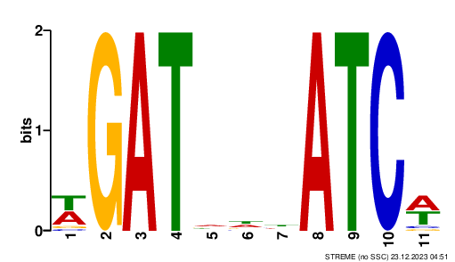

Figure 11: GATA3 motif variants at flanking–STREME

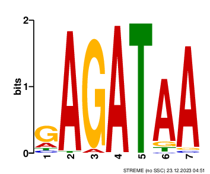

Figure 12: GATA3 motif variants at flanking–STREME

```bash
#!/bin/bash
#SBATCH --job-name=streme81N.sh
#SBATCH -N 1
#SBATCH -n 1
#SBATCH -c 32
#SBATCH -p himem
#SBATCH --qos=himem
#SBATCH --mem=128G
#SBATCH --mail-type=ALL
#SBATCH --mail-user=ssun@uchc.edu
#SBATCH -o streme81N.sh_%j.out
#SBATCH -e streme81N.sh_%j.err

hostname
export TMPDIR="${HOME}/temp"
module load meme/5.4.1

streme --o GATA3_without_motifs_123456_78_161bpwindow_81NNN_streme_output --nmotifs 10 --objfun de --bfile hg38_bkgrnd.txt --dna --minw 4 --maxw 20 --p without_motifs_123456_78_161bpwindow_81NNN.fasta
```

While running STREME on the flanking region, we got similar motifs out on the spanned region. This indicates that the previous 100bp window is not sufficient for finding all potential binding sites. Thus, we will `MAST` on the extended 161bp window (full) for all 8 motifs we found previously and see how many peaks remains.

# 6 Concatenate files

```bash
mkdir individual_meme
#MEME-round1 motif1
cp ../GATA_ChIP_top10000_motif.meme_output/meme.txt individual_meme/GATAmotif1_meme.txt
#MEME-round2 motif2
cp ../GATA3_without_motif1_top10000_output/meme.txt individual_meme/GATAmotif2_meme.txt
#MEME-round3 motif3
cp ../GATA3_without_motif12_top10000_output/meme.txt individual_meme/GATAmotif3_meme.txt
#MEME-round4 motif4
wget https://raw.githubusercontent.com/sysunn/siyu_daily_update/main/December_2023/MEME_individual_from_db_python3.py

python MEME_individual_from_db_python3.py -i ../GATA3_without_motif123_top10000_output_1/meme.txt
        # output: # AGATNDWNAGATARN_meme.txt ---motif4 (match to GATA3)
                  # TRTTTRCTYWD_meme.txt ---FOX
cp AGATNDWNAGATARN_meme.txt individual_meme/GATAmotif4_meme.txt

#MEME-round5 motif5
python MEME_individual_from_db_python3.py -i ../GATA3_without_motif1234_top10000_output/meme.txt
        # BTTATCWGATB_meme.txt    ---motif5 (match to GATA3)
cp BTTATCWGATB_meme.txt individual_meme/GATAmotif5_meme.txt

#MEME-round6 motif6
python MEME_individual_from_db_python3.py -i ../GATA3_without_motif12345_top10000_output/meme.txt
        # WGATBDHRVAGATAA_meme.txt    ---motif6 (match to GATA3)
cp WGATBDHRVAGATAA_meme.txt individual_meme/GATAmotif6_meme.txt


#STREME-round1 motif7
wget https://raw.githubusercontent.com/sysunn/siyu_daily_update/main/December_2023/STREME_individual_from_db_python3.py
python STREME_individual_from_db_python3.py -i ../GATA3_without_123456_streme_output/streme.txt
cp 4-AGATAAM_streme.txt individual_meme/AGATAAM_streme.txt
#STREME-round2 motif8
python STREME_individual_from_db_python3.py -i ../GATA3_without_123456_7_streme_output/streme.txt
cp 6-TGATAA_streme.txt individual_meme/TGATAA_streme.txt

rm *.txt #remove the non-used individual motifs
```

```bash
ls Exhaustive_MEME_MAST_round1to8/individual_meme
```

```
## AGATAAM_streme.txt
## GATAmotif1_meme.txt
## GATAmotif2_meme.txt
## GATAmotif3_meme.txt
## GATAmotif4_meme.txt
## GATAmotif5_meme.txt
## GATAmotif6_meme.txt
## TGATAA_streme.txt
```

This python script will concatenate all files in your directory, with common headers and each motif’s PSWMs.

```bash
wget https://raw.githubusercontent.com/sysunn/siyu_daily_update/main/December_2023/MEME_concatenate_motifs_to_db_python3.py
python MEME_concatenate_motifs_to_db_python3.py individual_meme/
```

```bash
head -20 Exhaustive_MEME_MAST_round1to8/combined_output_meme.txt
```

```
## MEME version 5.4.1 (Release date: Sat Aug 21 19:23:23 2021 -0700)
##
## ALPHABET= ACGT
##
## strands: + -
##
## A 0.295 C 0.205 G 0.205 T 0.295
##
## MOTIF AGATAARR
## letter-probability matrix: alength= 4 w= 8 nsites= 3784 E= 9.4e-672
## 0.756607  0.031184  0.000000  0.212209
## 0.000000  0.000000  1.000000  0.000000
## 1.000000  0.000000  0.000000  0.000000
## 0.000000  0.000000  0.000000  1.000000
## 0.999736  0.000000  0.000000  0.000264
## 0.998943  0.001057  0.000000  0.000000
## 0.272199  0.237051  0.490751  0.000000
## 0.394820  0.192653  0.222780  0.189746
##
## MOTIF WGATBDHRVAGATAA
```

## 6.1 MAST–161bp window

```bash
mast -hit_list -best combined_output_meme.txt without_motifs_123456_78_161bpwindow.fasta > mast_GATA3_PSWM_in_peaks_round9.txt

wget https://raw.githubusercontent.com/sysunn/siyu_daily_update/main/December_2023/parse_multi_mast_to_coordinates.R
Rscript parse_multi_mast_to_coordinates.R mast_GATA3_PSWM_in_peaks_round9.txt 8
```

```bash
wc -l Exhaustive_MEME_MAST_round1to8/mast_GATA3_PSWM_in_peaks_round9.txt
head -5 Exhaustive_MEME_MAST_round1to8/mast_GATA3_PSWM_in_peaks_round9.txt
wc -l Exhaustive_MEME_MAST_round1to8/mast_GATA3_PSWM_in_peaks_round9.bed #6002
head -5 Exhaustive_MEME_MAST_round1to8/mast_GATA3_PSWM_in_peaks_round9.bed
tail -5 Exhaustive_MEME_MAST_round1to8/mast_GATA3_PSWM_in_peaks_round9.bed
awk '{print $7}' Exhaustive_MEME_MAST_round1to8/mast_GATA3_PSWM_in_peaks_round9.bed | sort | uniq
```

```
##     6005 Exhaustive_MEME_MAST_round1to8/mast_GATA3_PSWM_in_peaks_round9.txt
## # Best single (non-overlapping) hit for each motif in all sequences from "without_motifs_123456_78_161bpwindow.fasta".
## # sequence_name (strand+/-)motif id alt_id hit_start hit_end score hit_p-value
## chr1:1859356-1859517 +5 AGATNDWNAGATARN - 25 39  1504.05 1.48e-05
## chr1:4649639-4649800 +7 WGATBTTATCW - 131 141  1752.50 1.54e-06
## chr1:6815710-6815871 +5 AGATNDWNAGATARN - 146 160  1541.45 1.14e-05
##     6002 Exhaustive_MEME_MAST_round1to8/mast_GATA3_PSWM_in_peaks_round9.bed
## chr1 11079884    11079891    1312.58 2.16e-05    +   1
## chr1 16608785    16608792    1230.47 6.56e-05    +   1
## chr1 23617371    23617378    1312.58 2.16e-05    -   1
## chr1 27144710    27144717    1312.58 2.16e-05    +   1
## chr1 27621448    27621455    1230.47 6.56e-05    +   1
## chrX 127236575   127236586   1302.18 3.4e-05 -   8
## chrX 132999248   132999259   1870.69 1.22e-07    -   8
## chrX 133325451   133325462   1674.65 3.44e-06    -   8
## chrX 134074641   134074652   1811.88 5.45e-07    -   8
## chrX 154074195   154074206   1321.78 2.96e-05    +   8
## 1
## 2
## 3
## 4
## 5
## 7
## 8
```

**Notice that here the motif indices 12345678 is following the motif’s PSWMs order in the concatenated database file.**

Use `intersectBed` with `-v` option to find peaks (161bp window) without motif 12345678.  
And convert to fasta.

```bash
# From peaks (without motif1, 2, 3, 4, 5, 6, 7, 8) (101bp window), exclude peaks with any of the motifs found in 161bp window
intersectBed -v -a without_motifs_123456_78_161bpwindow.bed -b mast_GATA3_PSWM_in_peaks_round9.bed > without_motifs_123456_78_161bp_mast.bed #37308
fastaFromBed -fi $genome -bed without_motifs_123456_78_161bp_mast.bed -fo without_motifs_123456_78_161bp_mast.fasta
```

```bash
wc -l Exhaustive_MEME_MAST_round1to8/without_motifs_123456_78_161bp_mast.bed
head -3 Exhaustive_MEME_MAST_round1to8/without_motifs_123456_78_161bp_mast.bed
wc -l Exhaustive_MEME_MAST_round1to8/without_motifs_123456_78_161bp_mast.fasta
head -6 Exhaustive_MEME_MAST_round1to8/without_motifs_123456_78_161bp_mast.fasta
```

```
##    37308 Exhaustive_MEME_MAST_round1to8/without_motifs_123456_78_161bp_mast.bed
## chr1 827300  827461  GATA_ChIP_peak_28   9.30478
## chr1 916689  916850  GATA_ChIP_peak_31   7.79887
## chr1 924773  924934  GATA_ChIP_peak_33   3.78065
##    74616 Exhaustive_MEME_MAST_round1to8/without_motifs_123456_78_161bp_mast.fasta
## >chr1:827300-827461
## CAGATCTGGCAGCTGAGCGACAGGCTTCGGAGCATTTCCGGGCGTCGCGGGACTCCCCGCCGACAGGAGGGCGGTTGCCGAGCCTGTGACATCCGCGGAGACCAGCAGACCCCGGGTGTGGAGGACGCCGCAGGGAGGGGACTGCGTGGCTGGGTTTGGCC
## >chr1:916689-916850
## CCTGGCAGCATGAGCGATGGCAGGCCCAGCGATAAGAAACTAATAATTTATGCTTCCAGCTCCCGGGGCCGGCGCCGAGGGAAGGTTGGGCCACAGCCTCCCCCGCACTGAGCGGCTGCAGTCCTTTATTGCACAAATTATTAACGACCAGAGAATGAATG
## >chr1:924773-924934
## TGCATCGAGGTGGAGTGCGGCGCCAACCGCGCGCTGCTCTACGTGCGCAAACTCTGCCAGGGCAGCAAGGGCCCGTCCATCCGCCACCGCGGCGAGTGGCTCACGCCCAACGAGTTCCAGTTCGTCAGCGGCCGCGAGACGGCCAAGGACTGGAAGCGCAG
```

# 7 Increase Width-181

In the previous analysis, we exhaustively ran MEME/STREME in a 101 bp window and found no GATA3-like motifs. We then extended the window from 101 bp to 161 bp and discovered similar motifs in the flanking region. This indicates that the previous 101 bp window was not large enough to find all possible binding sites of GATA3.

Now, after using `MAST` on all MEME/STREME found motifs in the 161 bp window, we are extending the width to 181 bp. Our aim is to perform a similar analysis to see if increasing the width to a 181 bp window will enable MEME/STREME to discover more possible binding sites.

```bash
module load bedtools
sizes=/home/FCAM/ssun/Genome/hg38.chrom.sizes
genome=/home/FCAM/ssun/Genome/hg38.fa

slopBed -b 10 -i without_motifs_123456_78_161bp_mast.bed -g $sizes  | sort -k1,1 -k2,2n > without_motifs_123456_78_181bpwindow.bed

fastaFromBed -fi $genome -bed without_motifs_123456_78_181bpwindow.bed -fo without_motifs_123456_78_181bpwindow.fasta
```

```bash
wc -l Exhaustive_MEME_MAST_round1to8/without_motifs_123456_78_181bpwindow.bed
head -5 Exhaustive_MEME_MAST_round1to8/without_motifs_123456_78_181bpwindow.bed

wc -l Exhaustive_MEME_MAST_round1to8/without_motifs_123456_78_181bpwindow.fasta
head -5 Exhaustive_MEME_MAST_round1to8/without_motifs_123456_78_181bpwindow.fasta
```

```
##    37308 Exhaustive_MEME_MAST_round1to8/without_motifs_123456_78_181bpwindow.bed
## chr1 827290  827471  GATA_ChIP_peak_28   9.30478
## chr1 916679  916860  GATA_ChIP_peak_31   7.79887
## chr1 924763  924944  GATA_ChIP_peak_33   3.78065
## chr1 966563  966744  GATA_ChIP_peak_34   3.78065
## chr1 999418  999599  GATA_ChIP_peak_36   2.11515
##    74616 Exhaustive_MEME_MAST_round1to8/without_motifs_123456_78_181bpwindow.fasta
## >chr1:827290-827471
## GACACAGACGCAGATCTGGCAGCTGAGCGACAGGCTTCGGAGCATTTCCGGGCGTCGCGGGACTCCCCGCCGACAGGAGGGCGGTTGCCGAGCCTGTGACATCCGCGGAGACCAGCAGACCCCGGGTGTGGAGGACGCCGCAGGGAGGGGACTGCGTGGCTGGGTTTGGCCACAAAAAGCG
## >chr1:916679-916860
## CCCGCCAGGCCCTGGCAGCATGAGCGATGGCAGGCCCAGCGATAAGAAACTAATAATTTATGCTTCCAGCTCCCGGGGCCGGCGCCGAGGGAAGGTTGGGCCACAGCCTCCCCCGCACTGAGCGGCTGCAGTCCTTTATTGCACAAATTATTAACGACCAGAGAATGAATGACTCTGTAAT
## >chr1:924763-924944
```

## 7.1 MEME-10,000 peaks on full 181 window

Perform MEME on top 10,000 peaks (full 181bp extended window).

```bash
# select top 10000
sort -nrk5,5 without_motifs_123456_78_181bpwindow.bed | head -n 10000 > without_motifs_123456_78_181bpwindow_top10000.bed
fastaFromBed -fi $genome -bed without_motifs_123456_78_181bpwindow_top10000.bed -fo without_motifs_123456_78_181bpwindow_top10000.fasta
```

```bash
#!/bin/bash
#SBATCH --job-name=meme181_1.sh
#SBATCH -N 8
#SBATCH -n 8
#SBATCH -c 25
#SBATCH -p general
#SBATCH --qos=general
#SBATCH --mem=50G
#SBATCH --mail-type=ALL
#SBATCH --mail-user=ssun@uchc.edu
#SBATCH -o meme181_1.sh_%j.out
#SBATCH -e meme181_1.sh_%j.err

hostname
export TMPDIR="${HOME}/temp"
module load meme/5.4.1

# MEME-classic
meme -p 200 -oc GATA3_without_motifs_123456_78_181bpwindow_top10000_meme_output1 -nmotifs 5 -objfun classic -csites 20000 -searchsize 0 -minw 4 -maxw 20 -revcomp -dna -bfile hg38_bkgrnd.txt -maxsize 100000000 without_motifs_123456_78_181bpwindow_top10000.fasta
```

## 7.2 MEME-10,000 peaks-on flanking region

As we discussed earlier, we want to increase MEME’s sensitivity in finding motifs at spanned region by replacing the central 141 bp sequences to 50 Ns.

```bash
#181window flank with central 141bp substituted with 50 Ns.
awk '!/^>/ { mid = int(length($0) / 2); $0 = substr($0, 1, mid - 71) "NNNNNNNNNNNNNNNNNNNNNNNNNNNNNNNNNNNNNNNNNNNNNNNNNN" substr($0, mid + 71); } 1' without_motifs_123456_78_181bpwindow_top10000.fasta > without_motifs_123456_78_181bpwindow_top10000_141NNN.fasta
```

```bash
head -8 Exhaustive_MEME_MAST_round1to8/without_motifs_123456_78_181bpwindow_top10000.fasta
head -8 Exhaustive_MEME_MAST_round1to8/without_motifs_123456_78_181bpwindow_top10000_141NNN.fasta
```

```
## >chr17:61336125-61336306
## CCCTGGTTTGCAAAGCAAACTTCAGCCTTTTACTATTTACCTTGGCAAGTCCAGGACCGGATTGATGATCTGTAAAGTGGATTTGTTATTTGGCTGTTTGCTTTGGCAGCTCTTGAAAGCACTTTGCTGATTACAGTCCCAGATGTCATTGCATACATTACCCTGCTCTATAACGGGGCTT
## >chr20:51715983-51716164
## ctatgggagatagaaatcagaaaagcagttgcctggggtggtgggggcgggtggggtgataggaacaggcaCTGGGgaacttcctggggtgatggaaatgttccatatcttgattgaggtggtatttatgtggaggctgacaaatgtcaaaactcaatgaactgaaaactgaagatctgtg
## >chr20:53786143-53786324
## CTTCTGATCCGATAACTTATTTGTTGGCAAAGCATGGTCCTGTGAATTCCTTTCTTGGCACCTAGGATCATTGCTTCAGCATCTGTTCTTTTAGAAAACAGGTTTGTCCAGCAACTTGTATTTGTCATCTTCCTTGTGATTTGTTTGATCAAGTACATTGTCTGTTAAGTTGAGTTGCTGC
## >chr20:53621505-53621686
## ACAAGCACACGTTATCAAGTGAATGAAATTCCTCTGGAAGCTATAAAATTGAAGATTGGAGGATGGCAGTGTTCAGATAGCATGAAAGGTTGCTCACTATTTAGGAATTTTTTTCAAAGCTAAGTTATTAATGAAAGCCAATTATTTGCACTTTTCCAGAAGGAAACACTGAGTCATTCAT
## >chr17:61336125-61336306
## CCCTGGTTTGCAAAGCAAANNNNNNNNNNNNNNNNNNNNNNNNNNNNNNNNNNNNNNNNNNNNNNNNNNCCCTGCTCTATAACGGGGCTT
## >chr20:51715983-51716164
## ctatgggagatagaaatcaNNNNNNNNNNNNNNNNNNNNNNNNNNNNNNNNNNNNNNNNNNNNNNNNNNactgaaaactgaagatctgtg
## >chr20:53786143-53786324
## CTTCTGATCCGATAACTTANNNNNNNNNNNNNNNNNNNNNNNNNNNNNNNNNNNNNNNNNNNNNNNNNNTCTGTTAAGTTGAGTTGCTGC
## >chr20:53621505-53621686
## ACAAGCACACGTTATCAAGNNNNNNNNNNNNNNNNNNNNNNNNNNNNNNNNNNNNNNNNNNNNNNNNNNAGGAAACACTGAGTCATTCAT
```

```bash
#!/bin/bash
#SBATCH --job-name=meme181_N1.sh
#SBATCH -N 8
#SBATCH -n 8
#SBATCH -c 20
#SBATCH -p general
#SBATCH --qos=general
#SBATCH --mem=40G
#SBATCH --mail-type=ALL
#SBATCH --mail-user=ssun@uchc.edu
#SBATCH -o meme181_N1.sh_%j.out
#SBATCH -e meme181_N1.sh_%j.err

hostname
export TMPDIR="${HOME}/temp"
module load meme/5.4.1

# MEME-classic
meme -p 160 -oc GATA3_without_motifs_123456_78_181bpwindow_141NNN_top10000_meme_output1 -nmotifs 5 -objfun classic -csites 20000 -searchsize 0 -minw 4 -maxw 20 -revcomp -dna -bfile hg38_bkgrnd.txt -maxsize 100000000 without_motifs_123456_78_181bpwindow_top10000_141NNN.fasta
```

No GATA3-like motifs found.

*While trying to search for `nmotifs 10` with parallel running, sbatch job failure: “Fatal error in PMPI_Allreduce”. But use `nmotifs 5` is fine.

## 7.3 STREME—full 181bp

```bash
#!/bin/bash
#SBATCH --job-name=streme181.sh
#SBATCH -N 1
#SBATCH -n 1
#SBATCH -c 32
#SBATCH -p general
#SBATCH --qos=general
#SBATCH --mem=128G
#SBATCH --mail-type=ALL
#SBATCH --mail-user=ssun@uchc.edu
#SBATCH -o streme181.sh_%j.out
#SBATCH -e streme181.sh_%j.err

hostname
export TMPDIR="${HOME}/temp"
module load meme/5.4.1

streme --o GATA3_without_motifs_123456_78_181bpwindow_streme_output --nmotifs 10 --objfun de --bfile hg38_bkgrnd.txt --dna --minw 4 --maxw 20 --p without_motifs_123456_78_181bpwindow.fasta
```

## 7.4 STREME—flanking

```bash
#181window flank with central 141bp substituted with 50 Ns.
awk '!/^>/ { mid = int(length($0) / 2); $0 = substr($0, 1, mid - 71) "NNNNNNNNNNNNNNNNNNNNNNNNNNNNNNNNNNNNNNNNNNNNNNNNNN" substr($0, mid + 71); } 1' without_motifs_123456_78_181bpwindow.fasta > without_motifs_123456_78_181bpwindow_141NNN.fasta
```

```bash
head -8 Exhaustive_MEME_MAST_round1to8/without_motifs_123456_78_181bpwindow.fasta
head -8 Exhaustive_MEME_MAST_round1to8/without_motifs_123456_78_181bpwindow_141NNN.fasta
```

```
## >chr1:827290-827471
## GACACAGACGCAGATCTGGCAGCTGAGCGACAGGCTTCGGAGCATTTCCGGGCGTCGCGGGACTCCCCGCCGACAGGAGGGCGGTTGCCGAGCCTGTGACATCCGCGGAGACCAGCAGACCCCGGGTGTGGAGGACGCCGCAGGGAGGGGACTGCGTGGCTGGGTTTGGCCACAAAAAGCG
## >chr1:916679-916860
## CCCGCCAGGCCCTGGCAGCATGAGCGATGGCAGGCCCAGCGATAAGAAACTAATAATTTATGCTTCCAGCTCCCGGGGCCGGCGCCGAGGGAAGGTTGGGCCACAGCCTCCCCCGCACTGAGCGGCTGCAGTCCTTTATTGCACAAATTATTAACGACCAGAGAATGAATGACTCTGTAAT
## >chr1:924763-924944
## CGGCGAGCCGTGCATCGAGGTGGAGTGCGGCGCCAACCGCGCGCTGCTCTACGTGCGCAAACTCTGCCAGGGCAGCAAGGGCCCGTCCATCCGCCACCGCGGCGAGTGGCTCACGCCCAACGAGTTCCAGTTCGTCAGCGGCCGCGAGACGGCCAAGGACTGGAAGCGCAGCATCCGCCAC
## >chr1:966563-966744
## CAGGAGGCTCCGGGCCTCCTTCTCCAGAAAGCCCTCGCTGAAGGGAAACAGGTGAGCGGGGCGTGGGTGCGGCCACCTGGGCGCAGGGCTCCCCCACCCGCTCCGGGGCCAAGCCACGAGACCCCTTGCCTTGTCCCCAGAGAGGACAGCGCGCGGATGTCGGCCGGCCTGCCGGGCCCCG
## >chr1:827290-827471
## GACACAGACGCAGATCTGGNNNNNNNNNNNNNNNNNNNNNNNNNNNNNNNNNNNNNNNNNNNNNNNNNNTGGGTTTGGCCACAAAAAGCG
## >chr1:916679-916860
## CCCGCCAGGCCCTGGCAGCNNNNNNNNNNNNNNNNNNNNNNNNNNNNNNNNNNNNNNNNNNNNNNNNNNGAGAATGAATGACTCTGTAAT
## >chr1:924763-924944
## CGGCGAGCCGTGCATCGAGNNNNNNNNNNNNNNNNNNNNNNNNNNNNNNNNNNNNNNNNNNNNNNNNNNTGGAAGCGCAGCATCCGCCAC
## >chr1:966563-966744
## CAGGAGGCTCCGGGCCTCCNNNNNNNNNNNNNNNNNNNNNNNNNNNNNNNNNNNNNNNNNNNNNNNNNNCGGCCGGCCTGCCGGGCCCCG
```

```bash
#!/bin/bash
#SBATCH --job-name=streme181_N.sh
#SBATCH -N 1
#SBATCH -n 1
#SBATCH -c 32
#SBATCH -p general
#SBATCH --qos=general
#SBATCH --mem=128G
#SBATCH --mail-type=ALL
#SBATCH --mail-user=ssun@uchc.edu
#SBATCH -o streme181_N.sh_%j.out
#SBATCH -e streme181_N.sh_%j.err

hostname
export TMPDIR="${HOME}/temp"
module load meme/5.4.1

streme --o GATA3_without_motifs_123456_78_181bpwindow_141NNN_streme_output --nmotifs 10 --objfun de --bfile hg38_bkgrnd.txt --dna --minw 4 --maxw 20 --p without_motifs_123456_78_181bpwindow_141NNN.fasta
```

STREME for the full 181 window and flanking region (central 141bp swapped to N) both found a motif with a “GAT” in it. But we do not think this is a potential binding site.

At this point, we can conclude that: GATA3 can bind **within 161bp** window around peak summit. Among the 96868 peaks called by MACS3, we have **~38.5%** GATA3 peaks do not contain MEME/STREME found GATA3 motifs.  
Then we can perform the kmer analysis to these 38.5% peaks and see if we can find specific GATA3 binding elements.

# 8 1 peak 1 motif

For peak in 101window, In each round, we have assigned each peak with one most enriched motif. For the remaining peaks, we have extended the window to 161bp, then mast for full 8 motifs’ database, and get 5545 more peaks with motifs.  
However, the `mast -best`, sometimes it will assign one peak with more than 1 different motif.  
In this analysis, the goal is to assign the best and only one motif for each peak. For peak assigned with more than 1 motif, we will select the “best” motif based on its distance to peak summit (and choose the more centered one).

A coherence check will be: test if the “best” motifs are not on central region, only on spanned region.

## 8.1 get peak in 161win with motifs

```bash
#mast -hit_list -best combined_output_meme.txt without_motifs_123456_78_161bpwindow.fasta > mast_GATA3_PSWM_in_peaks_round9.txt

#wget https://raw.githubusercontent.com/sysunn/siyu_daily_update/main/December_2023/parse_multi_mast_to_coordinates.R
#Rscript parse_multi_mast_to_coordinates.R mast_GATA3_PSWM_in_peaks_round9.txt 8
```

`mast` output file is peak sequences (161bp) with the best motif assigned.

```bash
head Exhaustive_MEME_MAST_round1to8/mast_GATA3_PSWM_in_peaks_round9.txt
```

```
## # Best single (non-overlapping) hit for each motif in all sequences from "without_motifs_123456_78_161bpwindow.fasta".
## # sequence_name (strand+/-)motif id alt_id hit_start hit_end score hit_p-value
## chr1:1859356-1859517 +5 AGATNDWNAGATARN - 25 39  1504.05 1.48e-05
## chr1:4649639-4649800 +7 WGATBTTATCW - 131 141  1752.50 1.54e-06
## chr1:6815710-6815871 +5 AGATNDWNAGATARN - 146 160  1541.45 1.14e-05
## chr1:6820004-6820165 +7 WGATBTTATCW - 124 134  1538.49 1.08e-05
## chr1:6820319-6820480 +7 WGATBTTATCW - 150 160  1441.21 2.20e-05
## chr1:7266109-7266270 +2 WGATBDHRVAGATAA - 26 40  1168.00 5.71e-05
## chr1:7326467-7326628 -7 WGATBTTATCW - 1 11  1480.12 1.65e-05
## chr1:7424709-7424870 +8 WGATAARVATCW - 149 160  1302.18 3.40e-05
```

Notice that there are peaks with more than one motif assigned (less unique peak regions than total peak regions).

```bash
cat Exhaustive_MEME_MAST_round1to8/mast_GATA3_PSWM_in_peaks_round9.txt | wc -l
cat Exhaustive_MEME_MAST_round1to8/mast_GATA3_PSWM_in_peaks_round9.txt | cut -f1 -d' ' | sort | uniq | wc -l
```

```
##     6005
##     5545
```

The parse_multi_mast_to_coordinates.R generates the motif coordinates associated the 161bp peak sequences.

```bash
head Exhaustive_MEME_MAST_round1to8/mast_GATA3_PSWM_in_peaks_round9.bed
```

```
## chr1 11079884    11079891    1312.58 2.16e-05    +   1
## chr1 16608785    16608792    1230.47 6.56e-05    +   1
## chr1 23617371    23617378    1312.58 2.16e-05    -   1
## chr1 27144710    27144717    1312.58 2.16e-05    +   1
## chr1 27621448    27621455    1230.47 6.56e-05    +   1
## chr1 29181010    29181017    1312.58 2.16e-05    +   1
## chr1 31038506    31038513    1312.58 2.16e-05    -   1
## chr1 31769385    31769392    1230.47 6.56e-05    +   1
## chr1 35475661    35475668    1230.47 6.56e-05    -   1
## chr1 39653754    39653761    1230.47 6.56e-05    +   1
```

We can use `intersectBed` to get peaks regions as well as the motif assigned to it.

```bash
module load bedtools
# From peaks (without motif1, 2, 3, 4, 5, 6, 7, 8) (101bp window), find peaks with any of the motifs found in 161bp window
intersectBed -wa -wb -a without_motifs_123456_78_161bpwindow.bed -b mast_GATA3_PSWM_in_peaks_round9.bed > without_motifs_123456_78_101bp_with_motifs_161bp_mast.bed

wc -l without_motifs_123456_78_101bp_with_motifs_161bp_mast.bed
#6005
head -5 without_motifs_123456_78_101bp_with_motifs_161bp_mast.bed
#chr1   1859356 1859517 GATA_ChIP_peak_75b  62.1909 chr1    1859381 18593951504.05  1.48e-05    +   5
#chr1   4649639 4649800 GATA_ChIP_peak_101  12.5259 chr1    4649770 46497801752.5   1.54e-06    +   7
#chr1   6815710 6815871 GATA_ChIP_peak_134  5.02874 chr1    6815856 68158701541.45  1.14e-05    +   5
#chr1   6820004 6820165 GATA_ChIP_peak_135a 88.3707 chr1    6820128 68201381538.49  1.08e-05    +   7
#chr1   6820319 6820480 GATA_ChIP_peak_135b 6.37157 chr1    6820469 68204791441.21  2.2e-05 +   7
```

## 8.2 isolate peaks that with more than one motif

get the set of peaks that has only 1 motif assigned.

```bash
awk 'NR==FNR{count[$4]++; next} count[$4]==1' without_motifs_123456_78_101bp_with_motifs_161bp_mast.bed without_motifs_123456_78_101bp_with_motifs_161bp_mast.bed > unique_without_motifs_123456_78_101bp_with_motifs_161bp_mast.bed
```

```bash
awk 'NR==FNR{count[$4]++; next} count[$4]==1' Exhaustive_MEME_MAST_round1to8/without_motifs_123456_78_101bp_with_motifs_161bp_mast.bed Exhaustive_MEME_MAST_round1to8/without_motifs_123456_78_101bp_with_motifs_161bp_mast.bed | wc -l
```

```
##     5093
```

get the set of peaks that has more than 1 motif assigned.

```bash
awk 'NR==FNR{count[$4]++; next} count[$4]>1' without_motifs_123456_78_101bp_with_motifs_161bp_mast.bed without_motifs_123456_78_101bp_with_motifs_161bp_mast.bed > dup_without_motifs_123456_78_101bp_with_motifs_161bp_mast.bed
```

```bash
awk 'NR==FNR{count[$4]++; next} count[$4]>1' Exhaustive_MEME_MAST_round1to8/without_motifs_123456_78_101bp_with_motifs_161bp_mast.bed Exhaustive_MEME_MAST_round1to8/without_motifs_123456_78_101bp_with_motifs_161bp_mast.bed | wc -l
```

```
##      912
```

```r
duplicated_peak <- read.table("Exhaustive_MEME_MAST_round1to8/dup_without_motifs_123456_78_101bp_with_motifs_161bp_mast.bed", header = FALSE, stringsAsFactors = FALSE)

head(duplicated_peak)
nrow(duplicated_peak)
```

## 8.3 for peak more than one motif, check the distance to peak summit (for each peak); then choose the motif that closer to peak summit as a better represented motif winthin that peak region

coherence check: the distances should all >50bp

Calculate the absolute distance between peak summits and motif summits, and keep only the one that the distance is smaller.

```r
calculate_distance <- function(peak_coords, motif_coords) {
  # Extract summit coordinates (assuming they are in the middle of the given ranges)
  peak_summit <- (peak_coords[, 2] + peak_coords[, 3]) / 2
  motif_summit <- (motif_coords[, 2] + motif_coords[, 3]) / 2

  # Calculate absolute distance
  abs_distance <- abs(peak_summit - motif_summit)

  return(abs_distance)
}


find_closest_motif <- function(peak_indices, df) {
  closest_rows <- list()

  for (peak_index in peak_indices) {
    # Filter rows based on the peak index
    subset_df <- df[df[, 4] == peak_index, ]

    if (nrow(subset_df) > 0) {
      # Calculate distances using the function
      distances <- calculate_distance(subset_df[, c(1, 2, 3)], subset_df[, c(6, 7, 8)])

      # Find the row with the smallest absolute distance
      closest_row <- subset_df[which.min(distances), ]
      # Add an extra column for the distance
      closest_row$distance <- min(distances)

      # Store the closest row in the list
      closest_rows[[as.character(peak_index)]] <- closest_row
    }
  }

  return(do.call(rbind, closest_rows))
}

closest_motif_rows <- find_closest_motif(unique(duplicated_peak$V4), duplicated_peak)
```

coherence check:

```r
summary(closest_motif_rows$distance)
```

There are 11 peaks with distance range from 1bp to 28bp, all associated with mast motif indice 8 (round2 motif 2).  
These peaks were not found when `mast` in the 101bp window peaks in round 2.

## 8.4 change mast motif indice to reflect the same indice as in round 1 to 8

```r
motif_round1=closest_motif_rows[closest_motif_rows$V12=="7", ]
motif_round2=closest_motif_rows[closest_motif_rows$V12=="8", ]
motif_round3=closest_motif_rows[closest_motif_rows$V12=="1", ]
motif_round4=closest_motif_rows[closest_motif_rows$V12=="5", ]
motif_round5=closest_motif_rows[closest_motif_rows$V12=="3", ]
motif_round6=closest_motif_rows[closest_motif_rows$V12=="2", ]
motif_round7=closest_motif_rows[closest_motif_rows$V12=="4", ]

nrow(motif_round1)
nrow(motif_round2)
nrow(motif_round3)
nrow(motif_round4)
nrow(motif_round5)
nrow(motif_round6)
nrow(motif_round7)
```

combine with the peaks (161bp) that uniquely assigned with only one motif.

```r
unique_peak <- read.table("Exhaustive_MEME_MAST_round1to8/unique_without_motifs_123456_78_101bp_with_motifs_161bp_mast.bed", header = FALSE, stringsAsFactors = FALSE)

head(unique_peak)
nrow(unique_peak)

#coherence check:
length(unique(unique_peak$V4))
```

```r
unique_motif_round1=unique_peak[unique_peak$V12=="7", ]
unique_motif_round2=unique_peak[unique_peak$V12=="8", ]
unique_motif_round3=unique_peak[unique_peak$V12=="1", ]
unique_motif_round4=unique_peak[unique_peak$V12=="5", ]
unique_motif_round5=unique_peak[unique_peak$V12=="3", ]
unique_motif_round6=unique_peak[unique_peak$V12=="2", ]
unique_motif_round7=unique_peak[unique_peak$V12=="4", ]

nrow(unique_motif_round1)
nrow(unique_motif_round2)
nrow(unique_motif_round3)
nrow(unique_motif_round4)
nrow(unique_motif_round5)
nrow(unique_motif_round6)
nrow(unique_motif_round7)
```

```r
motif_round1_161bp=rbind(unique_motif_round1, motif_round1[, 1:12])
motif_round2_161bp=rbind(unique_motif_round2, motif_round2[, 1:12])
motif_round3_161bp=rbind(unique_motif_round3, motif_round3[, 1:12])
motif_round4_161bp=rbind(unique_motif_round4, motif_round4[, 1:12])
motif_round5_161bp=rbind(unique_motif_round5, motif_round5[, 1:12])
motif_round6_161bp=rbind(unique_motif_round6, motif_round6[, 1:12])
motif_round7_161bp=rbind(unique_motif_round7, motif_round7[, 1:12])

nrow(motif_round1_161bp)
nrow(motif_round2_161bp)
nrow(motif_round3_161bp)
nrow(motif_round4_161bp)
nrow(motif_round5_161bp)
nrow(motif_round6_161bp)
nrow(motif_round7_161bp)


#coherence check:
nrow(rbind(motif_round1_161bp, motif_round2_161bp, motif_round3_161bp, motif_round4_161bp, motif_round5_161bp, motif_round6_161bp, motif_round7_161bp))
```

```r
write.table(motif_round1_161bp,file= 'with_motifs_1_161bp_mast.bed', quote=F,sep="\t",col.names=F,row.names=F)
write.table(motif_round2_161bp,file= 'with_motifs_2_161bp_mast.bed', quote=F,sep="\t",col.names=F,row.names=F)
write.table(motif_round3_161bp,file= 'with_motifs_3_161bp_mast.bed', quote=F,sep="\t",col.names=F,row.names=F)
write.table(motif_round4_161bp,file= 'with_motifs_4_161bp_mast.bed', quote=F,sep="\t",col.names=F,row.names=F)
write.table(motif_round5_161bp,file= 'with_motifs_5_161bp_mast.bed', quote=F,sep="\t",col.names=F,row.names=F)
write.table(motif_round6_161bp,file= 'with_motifs_6_161bp_mast.bed', quote=F,sep="\t",col.names=F,row.names=F)
write.table(motif_round7_161bp,file= 'with_motifs_7_161bp_mast.bed', quote=F,sep="\t",col.names=F,row.names=F)
```

## 8.5 101bp window peak with motif in round 1 to 8.

mast_GATA3_PSWM_in_peaks_round1.bed mast_GATA3_PSWM_in_peaks_round4.bed mast_GATA3_PSWM_in_peaks_round7.bed  
mast_GATA3_PSWM_in_peaks_round2.bed mast_GATA3_PSWM_in_peaks_round5.bed mast_GATA3_PSWM_in_peaks_round8.bed  
mast_GATA3_PSWM_in_peaks_round3.bed mast_GATA3_PSWM_in_peaks_round6.bed

These mast BED files store motif coordinates in 101bp peak window.

```bash
head -5 Exhaustive_MEME_MAST_round1to8/mast_GATA3_PSWM_in_peaks_round1.bed
```

```
## chr1 1080566 1080576 840.25  9.55e-05    +   1
## chr1 1238219 1238229 1413    9.62e-06    -   1
## chr1 1686405 1686415 1176    3.73e-05    -   1
## chr1 1741170 1741180 1176    3.73e-05    -   1
## chr1 2002016 2002026 1176    3.73e-05    +   1
```

We can use `intersectBed` to get peaks with motifs in 101bp window in the first 8 rounds.

Round1:

```bash
dir=/home/FCAM/ssun/GATA3_ChIP_PRO_July2023/ChIP_final/peak_call/
module load bedtools
# From peaks (without motif1, 2, 3, 4, 5, 6, 7, 8) (101bp window), find peaks with any of the motifs found in 161bp window
intersectBed -wa -wb -a ${dir}GATA_ChIP_summit_100window.bed -b mast_GATA3_PSWM_in_peaks_round1.bed > with_motifs_1_101bp_mast.bed

wc -l with_motifs_1_101bp_mast.bed
#11428
head -5 with_motifs_1_101bp_mast.bed
#chr1   1080506 1080607 GATA_ChIP_peak_45   6.37157 chr1    1080566 1080576 840.25  9.55e-05    +   1
#chr1   1238187 1238288 GATA_ChIP_peak_51   16.8938 chr1    1238219 1238229 1413    9.62e-06    -   1
#chr1   1686381 1686482 GATA_ChIP_peak_63   35.0463 chr1    1686405 1686415 1176    3.73e-05    -   1
#chr1   1741080 1741181 GATA_ChIP_peak_68   11.6965 chr1    1741170 1741180 1176    3.73e-05    -   1
#chr1   2001971 2002072 GATA_ChIP_peak_77   7.79887 chr1    2002016 2002026 1176    3.73e-05    +   1

#coherence check:
awk '{OFS="\t"} {print $1, $2, $3, $4}' with_motifs_1_101bp_mast.bed | sort | uniq | wc -l #11428
```

Round2:

```bash
intersectBed -wa -wb -a without_motifs_1.bed -b mast_GATA3_PSWM_in_peaks_round2.bed > with_motifs_2_101bp_mast.bed

wc -l with_motifs_2_101bp_mast.bed
#11467
head -5 with_motifs_2_101bp_mast.bed
#chr1   996099  996200  GATA_ChIP_peak_35   38.3686 chr1    996149  996160  1256.25 2.21e-05    +   1
#chr1   3213828 3213929 GATA_ChIP_peak_87   118.864 chr1    3213875 3213886 1455.15 5.8e-06 -   1
#chr1   5603406 5603507 GATA_ChIP_peak_106  2.64066 chr1    5603417 5603428 977.79  8.07e-05    -   1
#chr1   5688597 5688698 GATA_ChIP_peak_109  93.8407 chr1    5688630 5688641 1236.36 2.5e-05 +   1
#chr1   5959780 5959881 GATA_ChIP_peak_110  65.9829 chr1    5959797 5959808 1276.14 1.96e-05    -   1


#coherence check:
awk '{OFS="\t"} {print $1, $2, $3, $4}' with_motifs_2_101bp_mast.bed | sort | uniq | wc -l #10461

#there are peaks with more than one motif2 assigned
```

Round3:

```bash
intersectBed -wa -wb -a without_motifs_12.bed -b mast_GATA3_PSWM_in_peaks_round3.bed > with_motifs_3_101bp_mast.bed

wc -l with_motifs_3_101bp_mast.bed
#5202
head -5 with_motifs_3_101bp_mast.bed
#chr1   7912015 7912116 GATA_ChIP_peak_158  10.8826 chr1    7912050 7912057 1207.4  2.16e-05    -   1
#chr1   8395017 8395118 GATA_ChIP_peak_195  6.37157 chr1    8395075 8395082 1186.58 3.93e-05    +   1
#chr1   8571689 8571790 GATA_ChIP_peak_201b 18.377  chr1    8571741 8571748 1165.76 5.7e-05 -   1
#chr1   8635931 8636032 GATA_ChIP_peak_207  7.79887 chr1    8635951 8635958 1207.4  2.16e-05    -   1
#chr1   10507853    10507954    GATA_ChIP_peak_299b 10.0853 chr1    10507886    10507893    1207.4  2.16e-05    +   1


#coherence check:
awk '{OFS="\t"} {print $1, $2, $3, $4}' with_motifs_3_101bp_mast.bed | sort | uniq | wc -l #5202
```

Round4:

```bash
intersectBed -wa -wb -a without_motifs_123.bed -b mast_GATA3_PSWM_in_peaks_round4.bed > with_motifs_4_101bp_mast.bed

wc -l with_motifs_4_101bp_mast.bed
#5666
head -5 with_motifs_4_101bp_mast.bed
#chr1   869447  869548  GATA_ChIP_peak_30   3.78065 chr1    869468  869482  1223.57 5.03e-05    -   1
#chr1   917484  917585  GATA_ChIP_peak_32   75.0238 chr1    917504  917518  1111.37 7.37e-05    +   1
#chr1   3927027 3927128 GATA_ChIP_peak_98   14.2308 chr1    3927062 3927076 1691.04 2.59e-06    -   1
#chr1   4659215 4659316 GATA_ChIP_peak_102  54.7665 chr1    4659255 4659269 1691.04 2.59e-06    +   1
#chr1   5406545 5406646 GATA_ChIP_peak_103  3.78065 chr1    5406564 5406578 1747.14 1.19e-06    +   1


#coherence check:
awk '{OFS="\t"} {print $1, $2, $3, $4}' with_motifs_4_101bp_mast.bed | sort | uniq | wc -l #5665

#there are peaks with more than one motif4 assigned
```

Round5:

```bash
intersectBed -wa -wb -a without_motifs_1234.bed -b mast_GATA3_PSWM_in_peaks_round5.bed > with_motifs_5_101bp_mast.bed

wc -l with_motifs_5_101bp_mast.bed
#3564
head -5 with_motifs_5_101bp_mast.bed
#chr1   1858856 1858957 GATA_ChIP_peak_75a  32.8724 chr1    1858925 1858935 1196.17 5.23e-05    +   1
#chr1   3948545 3948646 GATA_ChIP_peak_99   53.5507 chr1    3948619 3948629 1469.94 1.62e-05    -   1
#chr1   6317549 6317650 GATA_ChIP_peak_118  14.2308 chr1    6317632 6317642 1433.43 2.15e-05    +   1
#chr1   8121132 8121233 GATA_ChIP_peak_179b 16.8938 chr1    8121183 8121193 1013.66 8.51e-05    -   1
#chr1   8137785 8137886 GATA_ChIP_peak_181  39.6542 chr1    8137811 8137821 1634.2  6.22e-06    +   1

#coherence check:
awk '{OFS="\t"} {print $1, $2, $3, $4}' with_motifs_5_101bp_mast.bed | sort | uniq | wc -l #3564
```

Round6:

```bash
intersectBed -wa -wb -a without_motifs_12345.bed -b mast_GATA3_PSWM_in_peaks_round6.bed > with_motifs_6_101bp_mast.bed

wc -l with_motifs_6_101bp_mast.bed
#4510
head -5 with_motifs_6_101bp_mast.bed
#chr1   6800878 6800979 GATA_ChIP_peak_133  261.961 chr1    6800916 6800930 1076.4  8.4e-05 -   1
#chr1   6959598 6959699 GATA_ChIP_peak_137  253.515 chr1    6959683 6959697 1644.31 4.74e-06    -   1
#chr1   8015116 8015217 GATA_ChIP_peak_161  378.26  chr1    8015155 8015169 1845.83 8.64e-07    -   1
#chr1   8312136 8312237 GATA_ChIP_peak_191  21.5896 chr1    8312221 8312235 1369.52 2.22e-05    +   1
#chr1   8421170 8421271 GATA_ChIP_peak_197  10.8826 chr1    8421203 8421217 1131.36 6.68e-05    -   1

#coherence check:
awk '{OFS="\t"} {print $1, $2, $3, $4}' with_motifs_6_101bp_mast.bed | sort | uniq | wc -l #4510
```

Round7:

```bash
intersectBed -wa -wb -a without_motifs_123456.bed -b mast_GATA3_PSWM_in_peaks_round7.bed > with_motifs_7_101bp_mast.bed

wc -l with_motifs_7_101bp_mast.bed
#8735
head -5 with_motifs_7_101bp_mast.bed
#chr1   845746  845847  GATA_ChIP_peak_29   541.83  chr1    845781  845787  1169.98 0.00027 +   1
#chr1   1504971 1505072 GATA_ChIP_peak_56   16.8938 chr1    1505049 1505055 1284.91 9.58e-05    +   1
#chr1   1746897 1746998 GATA_ChIP_peak_70   4.46672 chr1    1746948 1746954 724.65  0.000445    +   1
#chr1   3186510 3186611 GATA_ChIP_peak_86   15.1046 chr1    3186512 3186518 1284.91 9.58e-05    -   1
#chr1   6623397 6623498 GATA_ChIP_peak_126  26.5697 chr1    6623440 6623446 1241.81 0.000175    +   1


#coherence check:
awk '{OFS="\t"} {print $1, $2, $3, $4}' with_motifs_7_101bp_mast.bed | sort | uniq | wc -l #8733

#there are peaks with more than one motif7 assigned
```

Round8:

```bash
intersectBed -wa -wb -a without_motifs_123456_7.bed -b mast_GATA3_PSWM_in_peaks_round8.bed > with_motifs_8_101bp_mast.bed

wc -l with_motifs_8_101bp_mast.bed
#4454
head -5 with_motifs_8_101bp_mast.bed
#chr1   1775793 1775894 GATA_ChIP_peak_72   24.5459 chr1    1775856 1775861 1142.66 0.000349    +   1
#chr1   1855841 1855942 GATA_ChIP_peak_74   3.19627 chr1    1855920 1855925 1142.66 0.000349    +   1
#chr1   1883543 1883644 GATA_ChIP_peak_76   36.5894 chr1    1883563 1883568 1142.66 0.000349    -   1
#chr1   2135560 2135661 GATA_ChIP_peak_79   18.7357 chr1    2135607 2135612 1142.66 0.000349    -   1
#chr1   3613537 3613638 GATA_ChIP_peak_90   27.5967 chr1    3613592 3613597 1142.66 0.000349    -   1


#coherence check:
awk '{OFS="\t"} {print $1, $2, $3, $4}' with_motifs_8_101bp_mast.bed | sort | uniq | wc -l #4452

#there are peaks with more than one motif8 assigned
```

## 8.6 bar plot

Two bar plots: one is peak with motif 1, motif 2, …, motif 8; one is bar plot with more details (i.e., further separate peaks with motif1 to motif1 found in 101bp window, and motif1 found in 161 flanking regions).

```bash
touch peak.with.motif.240116.sum.txt
for i in with_motifs*_101bp_mast.bed
do
 nm=$(echo $i | awk -F"_101bp_mast.bed" '{print $1}' | awk -F"with_motifs_" '{print $2}' )
 p=$(awk '{OFS="\t"} {print $1, $2, $3, $4}' $i | sort | uniq | wc -l)
 echo "motif_${nm}_101bp" "" $p >> peak.with.motif.240116.sum.txt
done

for i in with_motifs*_161bp_mast.bed
do
 nm=$(echo $i | awk -F"_161bp_mast.bed" '{print $1}' | awk -F"with_motifs_" '{print $2}' )
 p=$(awk '{OFS="\t"} {print $1, $2, $3, $4}' $i | sort | uniq | wc -l)
 echo "motif_${nm}_161bp" "" $p >> peak.with.motif.240116.sum.txt
done

# peak withour motifs
wc -l without_motifs_123456_78_161bp_mast.bed
#37308 without_motifs_123456_78_161bp_mast.bed
head -5 without_motifs_123456_78_161bp_mast.bed
#chr1   827300  827461  GATA_ChIP_peak_28   9.30478
#chr1   916689  916850  GATA_ChIP_peak_31   7.79887
#chr1   924773  924934  GATA_ChIP_peak_33   3.78065
#chr1   966573  966734  GATA_ChIP_peak_34   3.78065
#chr1   999428  999589  GATA_ChIP_peak_36   2.11515

echo "without_motif" "" "37308" >> peak.with.motif.240116.sum.txt
```

```bash
cat peak.with.motif.240116.sum.txt
```

```
## motif_1_101bp  11428
## motif_2_101bp  10461
## motif_3_101bp  5202
## motif_4_101bp  5665
## motif_5_101bp  3564
## motif_6_101bp  4510
## motif_7_101bp  8733
## motif_8_101bp  4452
## motif_1_161bp  1042
## motif_2_161bp  1014
## motif_3_161bp  691
## motif_4_161bp  840
## motif_5_161bp  603
## motif_6_161bp  853
## motif_7_161bp  502
## without_motif  37308
```

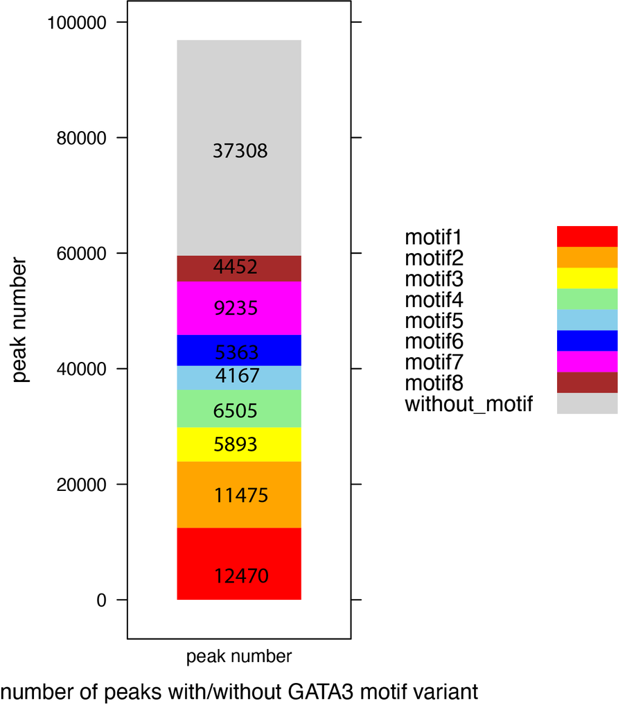

Figure 13: number of peaks with or without GATA3 motif variants

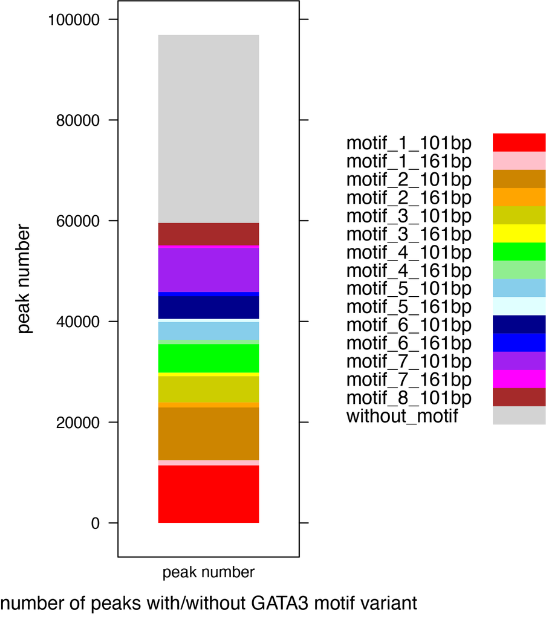

Figure 14: number of peaks with or without GATA3 motif variants

```r
#module load R/4.1.2
#R
library("lattice")
bar=read.table('peak.with.motif.240116.sum.txt', sep = "", header=F)
colnames(bar)=c("enriched_motifs", "peak_numbers")
bar$dum.x="peak number"
bar$enriched_motif<- factor(bar$enriched_motif, levels = c("motif_1_101bp", "motif_1_161bp", "motif_2_101bp", "motif_2_161bp", "motif_3_101bp", "motif_3_161bp", "motif_4_101bp", "motif_4_161bp", "motif_5_101bp", "motif_5_161bp", "motif_6_101bp", "motif_6_161bp", "motif_7_101bp",  "motif_7_161bp", "motif_8_101bp", "without_motif"))

#coherence check
sum(bar$peak_numbers) #96868

pdf('240116_peak_number_with_or_without_GATA3_motif_variant.pdf', width=5,height=6)
my.settings <- list(
  #superpose.polygon=list(col=c(colorRampPalette(c("red","pink"))(6),colorRampPalette(c("blue","light blue"))(3), "light grey"), border="transparent"),
  superpose.polygon=list(col=c("red","pink","orange3","orange","yellow3","yellow","green","lightgreen","skyblue","lightcyan","blue4","blue","purple","#FF00FF","brown","lightgrey"), border="transparent"),
  strip.background=list(col="grey80", cex = 0.6),
  strip.border=list(col="black")
)
print(barchart(peak_numbers ~ dum.x,
         data = bar,
         groups = enriched_motif,
         stack = TRUE,
         auto.key=list(space="right"),
         #scales = list(x = list(rot = 45)),
         ylab = "peak number",
         xlab = "number of peaks with/without GATA3 motif variant",
         par.settings = my.settings)
)
dev.off()

bar2=data.frame(matrix(ncol = 2, nrow = 9))
colnames(bar2)=c("enriched_motifs", "peak_numbers")
bar2$enriched_motifs=c("motif1","motif2","motif3","motif4","motif5","motif6","motif7","motif8","without_motif")
bar2$peak_numbers=c("12470","11475","5893","6505","4167","5363","9235","4452", "37308")
bar2$peak_numbers=as.numeric(bar2$peak_numbers)
bar2$dum.x="peak number"
bar2$enriched_motifs<- factor(bar2$enriched_motifs, levels = c("motif1","motif2","motif3","motif4","motif5","motif6","motif7","motif8","without_motif"))


pdf('240116_peak_number_with_or_without_GATA3_motif_variant2.pdf', width=5,height=6)
my.settings <- list(
  #superpose.polygon=list(col=c(colorRampPalette(c("red","pink"))(6),colorRampPalette(c("blue","light blue"))(3), "light grey"), border="transparent"),
  superpose.polygon=list(col=c("red","orange","yellow","lightgreen","skyblue","blue","#FF00FF","brown","lightgrey"), border="transparent"),
  strip.background=list(col="grey80", cex = 0.6),
  strip.border=list(col="black")
)
print(barchart(peak_numbers ~ dum.x,
         data = bar2,
         groups = enriched_motifs,
         stack = TRUE,
         auto.key=list(space="right"),
         #scales = list(x = list(rot = 45)),
         ylab = "peak number",
         xlab = "number of peaks with/without GATA3 motif variant",
         par.settings = my.settings)
)
dev.off()
```